# Concessão e Expansão do Aeroporto Internacional de Florianópolis

## 9.6 Trajetória do ATT com pool escalonado

Na especificação principal, todos os municípios com aeroporto concedido em qualquer rodada são excluídos do pool. Como robustez, cada seção é reestimada sob o critério “ainda não tratado”: um município concedido depois de Florianópolis permanece no pool até o ano da sua própria concessão.

Cada ponto da trajetória é um modelo SDID completo, com Florianópolis como única unidade tratada e janela pós-tratamento encerrada na data de corte. Os cortes ficam nos anos em que o pool muda (as rodadas de 2019, 2021 e 2022 que caem dentro da janela), e o último ponto usa a janela completa. Cada ponto tem pool e N0 próprios, e a leitura é de sensibilidade, sem correção para comparações múltiplas.

```r
ESTAGIONADO_SECOES <- local({
  municipal <- function(pool)
    list(mensal = FALSE, pool_bruto = pool, calendario = function() anac$anac_ano_tratamento)
  list(A = municipal(function() codigos_pool),
       B = municipal(function() codigos_pool),
       E = municipal(function() MUNICIPIOS_CAGED_BRUTO$cnae524))
})

# Campo do registro da trajetória escalonada de uma seção
cfg_escalonado <- function(id_base, campo) {
  cfg <- ESTAGIONADO_SECOES[[id_base]]
  if (is.null(cfg)) stop(sprintf("Secao-base '%s' sem registro escalonado", id_base))
  v <- cfg[[campo]]
  v <- if (is.function(v)) v() else v
  if (is.null(v)) {
    stop(sprintf("Trajetoria escalonada: campo '%s' indisponivel para a secao '%s'",
                 campo, id_base))
  }
  v
}

# Unidades candidatas da seção, antes da exclusão escalonada
ids_brutos_escalonado <- function(id_base) {
  as.character(as.integer(cfg_escalonado(id_base, "pool_bruto")))
}

# Unidade tratada da seção
tratado_escalonado <- function(id_base) MUNICIPIO_TRATADO

# Pool "ainda não tratado" de uma seção até o período de corte
pool_escalonado_secao <- function(id_base, periodo_fim) {
  cal      <- cfg_escalonado(id_base, "calendario")
  excluir  <- unidades_a_excluir_escalonado(cal, tratado_escalonado(id_base), periodo_fim)
  elegivel <- union(setdiff(ids_brutos_escalonado(id_base), excluir),
                    as.character(tratado_escalonado(id_base)))
  as.integer(elegivel)
}

# Datas de corte da trajetória: anos em que o pool muda
pontos_de_mudanca_escalonado <- function(id_base) {
  cal  <- cfg_escalonado(id_base, "calendario")
  base <- SECOES_TODAS[[id_base]]
  if (is.null(base)) stop(sprintf("Secao-base '%s' nao encontrada em SECOES_TODAS", id_base))

  bruto_id    <- ids_brutos_escalonado(id_base)
  valores_cal <- as.numeric(cal[intersect(names(cal), bruto_id)])
  candidatos  <- sort(unique(valores_cal[valores_cal > base$post[1] & valores_cal <= base$post[2]]))
  sort(unique(c(candidatos, base$post[2])))
}

# Estima um ponto da trajetória escalonada
executar_horizonte_escalonado <- function(id_base, periodo_fim, indice, salvar = TRUE) {
  id   <- sprintf("%s_esc_h%d", id_base, indice)
  base <- SECOES_TODAS[[id_base]]
  if (is.null(base)) stop(sprintf("Secao-base '%s' nao encontrada em SECOES_TODAS", id_base))
  stopifnot("periodo_fim deve ser >= inicio do pos-tratamento" = periodo_fim >= base$post[1])

  post_h <- c(base$post[1], periodo_fim)
  pool   <- pool_escalonado_secao(id_base, periodo_fim)

  COVARIAVEIS_POR_SECAO[[id]]    <<- conjunto_covariaveis(id_base)
  USAR_COVARIAVEIS_POR_SECAO[id] <<- usar_covariaveis(id_base)

  spec <- especificacao_secao(id, base$var)
  validar_covariaveis_secao(id, modifyList(base, list(post = post_h, pool = pool)),
                            spec, df_covariaveis)

  s <- list(
    var = base$var, pre = base$pre, post = post_h, pool = pool,
    dados        = dados_da_secao(base),
    tratado_nome = if (!is.null(base$tratado_nome)) base$tratado_nome else NOME_TRATADO,
    tratado_id   = if (!is.null(base$tratado_id))   base$tratado_id   else MUNICIPIO_TRATADO,
    calendario   = if (!is.null(base$calendario))   base$calendario   else anac$anac_ano_tratamento,
    modo = "escalonado_horizonte")

  message(sprintf(
    "  Horizonte %s: ate periodo %s, %d unidade(s) elegiveis, pos = [%s, %s]",
    id, periodo_fim, length(pool), post_h[1], post_h[2]))
  invalidar_cache_por_amostra(id, s)

  r <- roda_secao(
    id, s$var, s$pre, s$post,
    df_combinado          = s$dados,
    unidades_elegiveis    = s$pool,
    NOME_TRATADO          = s$tratado_nome,
    MUNICIPIO_TRATADO     = s$tratado_id,
    MODO_EXCLUSAO_ANAC    = "nenhum",
    calendario_tratamento = s$calendario,
    spec                = spec,
    ANO_TRATAMENTO      = ANO_TRATAMENTO,
    dir_saida           = DIR_SAIDA,
    fazer_event_study   = FALSE,
    fazer_loo           = fazer_loo_secao(id),
    variante_diag       = variante_diagnostico_secao(id)
  )
  stopifnot("roda_secao retornou NULL no horizonte escalonado" = !is.null(r))
  r$id_base     <- id_base
  r$periodo_fim <- periodo_fim
  if (salvar) salvar_saidas_secao(r, id)
  r
}

# Estima a trajetória completa de uma seção, um ponto por data de corte
trajetoria_escalonada_secao <- function(id_base, salvar = TRUE) {
  if (!isTRUE(EXECUTAR_ESCALONADO)) {
    message(sprintf("Secao %s: trajetoria escalonada desligada (EXECUTAR_ESCALONADO = FALSE)",
                    id_base))
    return(setNames(list(), character(0)))
  }
  if (!secao_ativa(id_base)) {
    message(sprintf("Secao %s inativa nesta execucao - trajetoria escalonada ignorada",
                    id_base))
    return(setNames(list(), character(0)))
  }

  pontos <- pontos_de_mudanca_escalonado(id_base)
  lista  <- vector("list", length(pontos))
  for (i in seq_along(pontos)) {
    lista[[i]] <- tryCatch(
      executar_horizonte_escalonado(id_base, pontos[i], i, salvar = salvar),
      error = function(e) {
        warning(sprintf("Trajetoria escalonada %s, horizonte %s: falhou - %s",
                        id_base, pontos[i], e$message))
        NULL
      })
  }
  setNames(lista, as.character(pontos))
}

# ATT, erro-padrão e p-valor do SDID de uma seção
extrair_att_secao <- function(r) {
  if (is.null(r)) return(NULL)
  spec <- spec_do_resultado(r)
  cv   <- if (isTRUE(spec$usar_covariaveis)) "com_cov" else "sem_cov"
  m    <- r[[cv]]$sdid
  if (is.null(m)) return(NULL)
  list(att = m$att, se = m$se, p = m$p)
}

# RMSE do ajuste pré-tratamento do SDID
rmse_pre_sdid <- function(r) {
  spec <- spec_do_resultado(r)
  base <- if (isTRUE(spec$usar_covariaveis)) r$com_cov else r$sem_cov
  est  <- base$sdid$est
  if (is.null(est)) return(NA_real_)
  gap <- tryCatch(gap_trajetoria_sdid(est), error = function(e) NULL)
  if (is.null(gap)) return(NA_real_)
  T0 <- attr(est, "setup")$T0
  sqrt(mean(gap[seq_len(T0)]^2, na.rm = TRUE))
}

# Linha da comparação entre o SDID principal e a trajetória escalonada
linha_comparacao_sdid <- function(r, especificacao, id_base) {
  m <- extrair_att_secao(r)
  if (is.null(m)) return(NULL)
  data.frame(
    Especificacao = especificacao,
    N0            = r$n_controles,
    T_pos         = r$post[2] - r$post[1] + 1L,
    ATT           = m$att,
    Efeito_pct    = efeito_pct(id_base, m$att),
    Erro_Padrao   = m$se,
    Estatistica_t = m$att / m$se,
    P_valor       = m$p,
    RMSE_pre      = rmse_pre_sdid(r),
    stringsAsFactors = FALSE
  )
}

# Comparação entre o SDID principal e cada ponto da trajetória
tab_comparacao_sdid <- function(lista_escalonada, id_base, resultado_principal = NULL) {
  if (is.null(resultado_principal)) {
    resultado_principal <- if (exists("resultados")) resultados[[id_base]] else NULL
  }

  linhas <- list(linha_comparacao_sdid(resultado_principal, "Principal (binario)", id_base))
  for (r in lista_escalonada) {
    if (is.null(r)) next
    linhas[[length(linhas) + 1L]] <- linha_comparacao_sdid(
      r, sprintf("Escalonado \u00b7 pool ate %s", rotulo_horizonte(id_base, r$periodo_fim)),
      id_base)
  }
  linhas <- Filter(Negate(is.null), linhas)
  if (length(linhas) == 0) {
    return(aviso_indisponivel("Sem resultados para comparar principal x escalonado."))
  }

  tab <- do.call(rbind, linhas)
  att_principal <- if (grepl("^Principal", tab$Especificacao[1])) tab$ATT[1] else NA_real_

  tab$Delta_ATT   <- tab$ATT - att_principal
  tab$Sinal_igual <- ifelse(is.na(att_principal) | tab$ATT == 0, NA,
                            sign(tab$ATT) == sign(att_principal))
  tab$Principal_no_IC95 <- !is.na(att_principal) &
    att_principal >= tab$ATT - 1.96 * tab$Erro_Padrao &
    att_principal <= tab$ATT + 1.96 * tab$Erro_Padrao

  tab$Delta_ATT[1] <- NA_real_
  tab$Sinal_igual[1] <- NA
  tab$Principal_no_IC95[1] <- NA

  tab <- arredondar_colunas(tab, c(ATT = 4, Efeito_pct = 2, Erro_Padrao = 4,
                                   Estatistica_t = 3, P_valor = 3,
                                   RMSE_pre = 4, Delta_ATT = 4))
  tab$Significancia <- estrelas_significancia(tab$P_valor)

  exportar_csv(tab,
               file.path(dir_secao(DIR_SAIDA, id_base),
                         sprintf("%s_comparacao_escalonado.csv", slug_secao(id_base))),
               sprintf("%s / comparacao principal x escalonado", id_base))

  knitr::kable(tab, row.names = FALSE,
               caption = sprintf("%s - SDID principal x versoes escalonadas",
                                 rotulo_secao(id_base)))
}

# Rótulo de um ponto de corte
rotulo_horizonte <- function(id_base, periodo_fim) {
  if (isTRUE(ESTAGIONADO_SECOES[[id_base]]$mensal)) rotulo_mensal(periodo_fim)
  else as.character(periodo_fim)
}

# Tabela da trajetória de ATT por horizonte
tab_trajetoria_escalonada <- function(lista, id_base) {
  linhas <- Filter(Negate(is.null), lapply(lista, function(r) {
    m <- extrair_att_secao(r)
    if (is.null(m)) return(NULL)
    data.frame(Horizonte = rotulo_horizonte(id_base, r$periodo_fim),
              N_controles = r$n_controles, ATT = m$att,
              Efeito_pct = efeito_pct(id_base, m$att), Erro_Padrao = m$se,
              Estatistica_t = m$att / m$se, P_valor = m$p, stringsAsFactors = FALSE)
  }))
  if (length(linhas) == 0) {
    return(aviso_indisponivel("Sem pontos validos na trajetoria escalonada."))
  }
  tab <- do.call(rbind, linhas)
  tab <- arredondar_colunas(tab, c(ATT = 4, Efeito_pct = 2, Erro_Padrao = 4,
                                   Estatistica_t = 3, P_valor = 3))
  tab$Significancia <- estrelas_significancia(tab$P_valor)
  knitr::kable(tab, row.names = FALSE,
               caption = sprintf(
                 "%s - ATT por horizonte sob pool escalonado (ainda-nao-tratado)",
                 rotulo_secao(id_base)))
}

# Gráfico da trajetória de ATT por horizonte, com IC 95%
desenhar_trajetoria_escalonada <- function(lista, id_base, titulo = NULL) {
  pontos <- Filter(Negate(is.null), lapply(lista, function(r) {
    m <- extrair_att_secao(r)
    if (is.null(m)) return(NULL)
    data.frame(horizonte = r$periodo_fim, att = m$att, se = m$se, n0 = r$n_controles)
  }))
  if (length(pontos) == 0) {
    message(sprintf("Secao %s: sem pontos validos para a trajetoria escalonada", id_base))
    return(placeholder_grafico(
      sprintf("Secao %s: trajetoria escalonada indisponivel", id_base)))
  }
  d <- do.call(rbind, pontos)
  d <- d[order(d$horizonte), ]
  d$lo <- d$att - 1.96 * d$se
  d$hi <- d$att + 1.96 * d$se

  d$rotulo <- factor(vapply(d$horizonte, function(h) rotulo_horizonte(id_base, h),
                            character(1)),
                     levels = vapply(d$horizonte,
                                     function(h) rotulo_horizonte(id_base, h),
                                     character(1)))

  if (is.null(titulo)) {
    titulo <- sprintf("%s - ATT por horizonte (pool escalonado)", rotulo_secao(id_base))
  }

  ggplot2::ggplot(d, ggplot2::aes(x = rotulo, y = att)) +
    ggplot2::geom_hline(yintercept = 0, colour = "grey45",
                        linetype = "dashed", linewidth = 0.4) +
    ggplot2::geom_line(ggplot2::aes(group = 1), colour = cor_de("tratado"),
                       linewidth = 0.5, alpha = 0.6) +
    ggplot2::geom_pointrange(ggplot2::aes(ymin = lo, ymax = hi),
                             colour = cor_de("tratado"), size = 0.45,
                             linewidth = 0.6) +
    ggplot2::geom_text(ggplot2::aes(y = hi, label = sprintf("N0=%d", n0)),
                       vjust = -0.8, size = 2.9, colour = "grey30") +
    ggplot2::scale_y_continuous(expand = ggplot2::expansion(mult = 0.18),
                                labels = formato_br()) +
    ggplot2::labs(title = titulo,
                  subtitle = "Barras: IC 95% (erro-padrao por placebo)",
                  x = "Fim do horizonte (pool ainda-nao-tratado ate aqui)",
                  y = "ATT (SDID)") +
    tema_tcc()
}
```

# 10 Pools restritos por intensidade setorial

O SDID escolhe os pesos `omega` para reproduzir a trajetória pré-tratamento de Florianópolis, mas isso não garante que os doadores tenham a mesma exposição a choques posteriores. A janela pós inclui a pandemia, que afetou de forma diferente os destinos turísticos, e o crescimento do setor de tecnologia em Florianópolis. Os pools restritos mantêm variável, janelas, painel e inferência das seções A e B e alteram apenas o conjunto de doadores.

Com uma unidade tratada e enumeração exata dos placebos, o menor p-valor atingível é $1/(N_0+1)$; rejeitar a hipótese nula a 5% exige $N_0 \ge 19$. Esse piso orienta a escolha dos calipers.

## 10.1 Pool turístico

O índice é a densidade de vínculos em alojamento (CNAE 55) por mil habitantes, medida no período pré-tratamento (média de 2013 a 2016). Alojamento é a atividade com maior participação de consumo de visitantes; o estoque da RAIS foi preferido aos fluxos do CAGED porque admissões misturam tamanho do setor e rotatividade, que é maior em destinos sazonais. Duas limitações: a hotelaria também atende viagens de negócios, de modo que o critério seleciona municípios com hotelaria intensa em relação ao porte, e não necessariamente destinos de lazer; e Florianópolis é a primeira colocada do pool nesse índice, cerca de 2,5 desvios-padrão acima da média dos doadores, de modo que o SDID extrapola nessa dimensão.

### 10.1.1 Escolha do caliper

```r
tab_grade_caliper_turismo()
```

Sensibilidade do pool ao caliper. `p_minimo` = 1/(N0+1) e’ o menor p-valor atingivel com enumeracao exata dos placebos; `Atinge_5pct` exige N0 >= 19. Sem expansao automatica.

| Caliper_dp | N0 | p_minimo | Dens_min | Dens_max | Atinge_5pct |
| --- | --- | --- | --- | --- | --- |
| 1.00 | 3 | 0.250 | 3.73 | 6.48 | FALSE |
| 1.50 | 6 | 0.143 | 2.27 | 6.48 | FALSE |
| 2.00 | 22 | 0.043 | 1.50 | 6.48 | TRUE |
| 2.25 | 28 | 0.034 | 1.19 | 6.48 | TRUE |

O caliper adotado é de 2,00 desvios-padrão, o menor valor da grade que atende ao piso de $N_0 \ge 19$. Nesse valor o filtro remove a parte inferior da distribuição, mas não seleciona um grupo estreito de pares.

### 10.1.2 Composição do pool

```r
tab_pool_turismo()
```

Pool turistico: N0 = 22, caliper 2.00 dp. `z` e’ padronizado nos DOADORES (tratado excluido da media e do desvio-padrao).

| Municipio | Papel | Estoque_55 | Anos | Pop_pre | Dens_mil_hab | z |
| --- | --- | --- | --- | --- | --- | --- |
| Florianópolis | tratado | 3775 | 4 | 465485 | 8.11 | 2.52 |
| Natal | controle | 5614 | 4 | 865852 | 6.48 | 2.26 |
| Petrópolis | controle | 1166 | 4 | 298051 | 3.91 | 1.67 |
| Camaçari | controle | 1058 | 4 | 283929 | 3.73 | 1.62 |
| Cuiabá | controle | 1889 | 4 | 577763 | 3.27 | 1.46 |
| Chapecó | controle | 509 | 4 | 203842 | 2.50 | 1.15 |
| Maringá | controle | 894 | 4 | 394435 | 2.27 | 1.04 |
| Ribeirão Preto | controle | 1470 | 4 | 662021 | 2.22 | 1.01 |
| Santos | controle | 944 | 4 | 433761 | 2.18 | 0.99 |
| Olinda | controle | 842 | 4 | 389146 | 2.16 | 0.98 |
| Niterói | controle | 1053 | 4 | 496060 | 2.12 | 0.96 |
| Belo Horizonte | controle | 5242 | 4 | 2496538 | 2.10 | 0.95 |
| Embu das Artes | controle | 524 | 4 | 260364 | 2.01 | 0.90 |
| Caucaia | controle | 680 | 4 | 351605 | 1.94 | 0.85 |
| Itajaí | controle | 391 | 4 | 203356 | 1.92 | 0.84 |
| Presidente Prudente | controle | 410 | 4 | 221368 | 1.85 | 0.80 |
| Sete Lagoas | controle | 403 | 4 | 230933 | 1.75 | 0.73 |
| Indaiatuba | controle | 399 | 4 | 228707 | 1.74 | 0.73 |
| Blumenau | controle | 566 | 4 | 336375 | 1.68 | 0.69 |
| Itabuna | controle | 357 | 4 | 219277 | 1.63 | 0.65 |
| Barueri | controle | 416 | 4 | 260862 | 1.60 | 0.63 |
| São José do Rio Preto | controle | 684 | 4 | 440372 | 1.55 | 0.60 |
| Anápolis | controle | 545 | 4 | 364155 | 1.50 | 0.55 |

A coluna `z` indica a posição de cada município no índice padronizado.

## 10.2 Pool tecnológico

O índice é a densidade de vínculos em tecnologia da informação e serviços de informação (CNAE 62 e 63) por mil habitantes, com o mesmo procedimento do índice turístico, também medida no período pré-tratamento (média de 2013 a 2016). O setor de tecnologia passou de cerca de 14% para cerca de 25% do PIB de Florianópolis entre 2019 e 2023, dentro da janela pós-tratamento. Nenhum dos filtros do pool principal seleciona por estrutura setorial, e o contrafactual irrestrito pode não ter intensidade tecnológica comparável. Florianópolis tem 36,68 vínculos por mil habitantes nesse índice, a segunda maior do pool (atrás de Barueri), cerca de 2,46 desvios-padrão acima da média dos doadores.

O viés turístico e o tecnológico têm sinais opostos sobre o ATT e por isso não se compensam automaticamente; os cenários são reportados separadamente.

### 10.2.1 Escolha do caliper

```r
tab_grade_caliper_tecnologia()
```

Sensibilidade do pool ao caliper tecnologico. `p_minimo` = 1/(N0+1) e’ o menor p-valor atingivel com enumeracao exata dos placebos; `Atinge_5pct` exige N0 >= 19. Sem expansao automatica.

| Caliper_dp | N0 | p_minimo | Dens_min | Dens_max | Atinge_5pct |
| --- | --- | --- | --- | --- | --- |
| 1.00 | 4 | 0.200 | 9.83 | 84.8 | FALSE |
| 1.50 | 10 | 0.091 | 3.72 | 84.8 | FALSE |
| 2.00 | 24 | 0.040 | 1.73 | 84.8 | TRUE |
| 2.25 | 30 | 0.032 | 1.18 | 84.8 | TRUE |
| 2.50 | 32 | 0.030 | 1.01 | 84.8 | TRUE |

O caliper de 2,00 desvios-padrão, igual ao turístico, resulta em N0 = 24, acima do piso de 19.

### 10.2.2 Composição do pool

```r
tab_pool_tecnologia()
```

Pool tecnologico: N0 = 24, caliper 2.00 dp. `z` e’ padronizado nos DOADORES (tratado excluido da media e do desvio-padrao).

| Municipio | Papel | Estoque_62_63 | Anos | Pop_pre | Dens_mil_hab | z |
| --- | --- | --- | --- | --- | --- | --- |
| Barueri | controle | 22122 | 4 | 260862 | 84.80 | 3.00 |
| Florianópolis | tratado | 17075 | 4 | 465485 | 36.68 | 2.46 |
| Jundiaí | controle | 8192 | 4 | 399856 | 20.49 | 2.09 |
| Blumenau | controle | 4727 | 4 | 336375 | 14.05 | 1.84 |
| Americana | controle | 2242 | 4 | 228101 | 9.83 | 1.61 |
| Belo Horizonte | controle | 19489 | 4 | 2496538 | 7.81 | 1.46 |
| São Leopoldo | controle | 1760 | 4 | 227634 | 7.73 | 1.46 |
| São Bernardo do Campo | controle | 5909 | 4 | 814115 | 7.26 | 1.42 |
| Cuiabá | controle | 3057 | 4 | 577763 | 5.29 | 1.21 |
| Maringá | controle | 1891 | 4 | 394435 | 4.79 | 1.15 |
| Chapecó | controle | 759 | 4 | 203842 | 3.72 | 0.98 |
| Taboão da Serra | controle | 931 | 4 | 270165 | 3.45 | 0.93 |
| Novo Hamburgo | controle | 828 | 4 | 248459 | 3.33 | 0.91 |
| Ribeirão Preto | controle | 2146 | 4 | 662021 | 3.24 | 0.89 |
| Niterói | controle | 1461 | 4 | 496060 | 2.95 | 0.83 |
| Maracanaú | controle | 644 | 4 | 220582 | 2.92 | 0.83 |
| São José do Rio Preto | controle | 1165 | 4 | 440372 | 2.64 | 0.76 |
| Natal | controle | 2244 | 4 | 865852 | 2.59 | 0.75 |
| Jaboatão dos Guararapes | controle | 1704 | 4 | 683423 | 2.49 | 0.72 |
| Aparecida de Goiânia | controle | 1277 | 4 | 516363 | 2.47 | 0.72 |
| Osasco | controle | 1606 | 4 | 694035 | 2.31 | 0.68 |
| Cotia | controle | 442 | 4 | 227323 | 1.95 | 0.56 |
| Contagem | controle | 1227 | 4 | 645974 | 1.90 | 0.55 |
| Indaiatuba | controle | 407 | 4 | 228707 | 1.78 | 0.51 |
| Santo André | controle | 1224 | 4 | 708873 | 1.73 | 0.49 |

## 10.3 Pool misto

O pool misto restringe as duas dimensões ao mesmo tempo pela distância de Mahalanobis no plano (intensidade turística, intensidade tecnológica), os dois índices medidos no período pré-tratamento, com a covariância calculada nos doadores. A interseção dos dois pools univariados foi descartada porque as duas densidades são positivamente correlacionadas, e a interseção penalizaria duas vezes a mesma informação. A distância de Mahalanobis permanece na escala de desvios-padrão, comparável aos calipers univariados.

### 10.3.1 Escolha do caliper

```r
tab_grade_caliper_misto()
```

Sensibilidade do pool ao caliper misto (distancia de Mahalanobis no plano turismo x tecnologia). `p_minimo` = 1/(N0+1) e’ o menor p-valor atingivel com enumeracao exata dos placebos; `Atinge_5pct` exige N0 >= 19. Sem expansao automatica - `pool_caliper_bivariado()` expande na estimacao real.

| Caliper_dp | N0 | p_minimo | Atinge_5pct |
| --- | --- | --- | --- |
| 1.5 | 1 | 0.500 | FALSE |
| 2.0 | 8 | 0.111 | FALSE |
| 2.5 | 23 | 0.042 | TRUE |
| 3.0 | 35 | 0.028 | TRUE |

### 10.3.2 Sobreposição entre os critérios

```r
tab_sobreposicao_pools()
```

Sobreposicao dos criterios de pool: turistico, tecnologico, intersecao (diagnostico), uniao, e o pool misto efetivamente usado na estimacao (Mahalanobis).

| Criterio | N0 | p_minimo |
| --- | --- | --- |
| Turistico | 22 | 0.043 |
| Tecnologico | 24 | 0.040 |
| Intersecao (diagnostico) | 11 | 0.083 |
| Uniao | 35 | 0.028 |
| Mahalanobis (estimado) | 19 | 0.050 |

A tabela mostra quanto os pools turístico e tecnológico se sobrepõem entre si e em relação ao pool misto. É um diagnóstico; o pool de estimação é o misto.

### 10.3.3 Composição do pool

```r
tab_pool_misto()
```

Pool misto: N0 = 19, caliper 2.40 dp (Mahalanobis) (alargado de 2.00). Correlacao dos indices nos doadores = +0.50.

| Municipio | Papel | Dens_turistica | Dens_tecnologica |
| --- | --- | --- | --- |
| Florianópolis | tratado | 8.11 | 36.68 |
| Jundiaí | controle | 1.30 | 20.49 |
| Blumenau | controle | 1.68 | 14.05 |
| Belo Horizonte | controle | 2.10 | 7.81 |
| São Leopoldo | controle | 1.42 | 7.73 |
| Cuiabá | controle | 3.27 | 5.29 |
| Maringá | controle | 2.27 | 4.79 |
| Chapecó | controle | 2.50 | 3.72 |
| Ribeirão Preto | controle | 2.22 | 3.24 |
| Niterói | controle | 2.12 | 2.95 |
| São José do Rio Preto | controle | 1.55 | 2.64 |
| Natal | controle | 6.48 | 2.59 |
| Jaboatão dos Guararapes | controle | 1.19 | 2.49 |
| Aparecida de Goiânia | controle | 1.44 | 2.47 |
| Indaiatuba | controle | 1.74 | 1.78 |
| Santos | controle | 2.18 | 1.55 |
| Petrópolis | controle | 3.91 | 1.28 |
| Embu das Artes | controle | 2.01 | 1.18 |
| Presidente Prudente | controle | 1.85 | 1.13 |
| Itajaí | controle | 1.92 | 1.01 |

# 11 Seção A — PIB per capita

Variável dependente: log do PIB per capita municipal, de 2013 a 2016 (pré) e de 2017 a 2023 (pós). O efeito é reportado como variação percentual, $(e^{ATT} - 1) \times 100$.

```r
resultados$A <- executar_secao("A")
```

## 11.1 Ficha da seção

```r
tab_ficha(resultados$A)
```

Secao A - ficha da estimacao

| Item | Valor |
| --- | --- |
| Variavel dependente | log_pib_per_capita |
| Especificacao | log_pib_per_capita ~ tratado:pos |
| Covariaveis | desativadas |
| Conjunto de covariaveis | - |
| Variante dos diagnosticos | SDID sem covariaveis (sem_cov) |
| Janela pre-tratamento | 2013-2016 |
| Janela pos-tratamento | 2017-2023 |
| Ano de tratamento | 2017 |
| Unidade tratada | Florianópolis (4205407) |
| Controles no painel | 68 |
| Escala do efeito | (exp(ATT)-1)*100 - variacao % |
| Event study | estimado (sem_cov) |
| Leave-one-out | estimado (sem_cov) |

## 11.2 ATT por método

`Erro_Padrao` é o erro-padrão por placebo. A última linha traz o erro-padrão jackknife do leave-one-out, como diagnóstico complementar.

```r
tab_resultados(resultados$A)
```

Secao A - ATT por metodo e variante de covariaveis

| Secao | Variavel | Covariaveis | Modelo | Coeficiente | Efeito_pct | Erro_Padrao | Estatistica_t | P_valor | SE_placebo | IC95_quantil | Significancia |
| --- | --- | --- | --- | --- | --- | --- | --- | --- | --- | --- | --- |
| A | log_pib_per_capita | sem_cov | SDID | -0.0714 | -6.89 | 0.1051 | -0.679 | 0.497 | exaustivo | [-0.267; 0.087] |  |
| A | log_pib_per_capita | sem_cov | SC | -0.0349 | -3.43 | 0.1294 | -0.270 | 0.787 | exaustivo | [-0.357; 0.148] |  |
| A | log_pib_per_capita | sem_cov | DID | -0.0619 | -6.01 | 0.1140 | -0.544 | 0.587 | exaustivo | [-0.285; 0.090] |  |
| A | log_pib_per_capita | event_study | RMSPE_ratio | 28.4118 | NA | NA | NA | 0.072 | NA | NA | * |
| A | log_pib_per_capita | sem_cov | SDID (SE jackknife via LOO) | -0.0714 | -6.89 | 0.0121 | -5.876 | 0.000 | NA | NA | *** |

## 11.3 Pesos do controle sintético

Pesos `omega` do SDID. São os mesmos usados no event study e no leave-one-out.

```r
tab_pesos(resultados$A)
```

Secao A - pesos do controle sintetico sem covariaveis (todas as unidades do pool; vetor completo; a coluna soma 1)

| Municipio | Peso_SDID |
| --- | --- |
| Suzano | 0.0230 |
| Duque de Caxias | 0.0227 |
| Petrópolis | 0.0216 |
| Osasco | 0.0208 |
| Mauá | 0.0203 |
| Camaçari | 0.0201 |
| Itapevi | 0.0201 |
| Ananindeua | 0.0198 |
| Juazeiro | 0.0196 |
| Viamão | 0.0192 |
| Cuiabá | 0.0187 |
| Embu das Artes | 0.0186 |
| Chapecó | 0.0182 |
| Blumenau | 0.0182 |
| Itaquaquecetuba | 0.0182 |
| Aparecida de Goiânia | 0.0181 |
| Alvorada | 0.0181 |
| São Leopoldo | 0.0176 |
| Colombo | 0.0173 |
| Ribeirão das Neves | 0.0171 |
| Itajaí | 0.0168 |
| Jundiaí | 0.0163 |
| Cariacica | 0.0158 |
| Indaiatuba | 0.0158 |
| Santos | 0.0157 |
| Serra | 0.0154 |
| Ribeirão Preto | 0.0153 |
| Nova Iguaçu | 0.0153 |
| Hortolândia | 0.0153 |
| Gravataí | 0.0149 |
| Parnamirim | 0.0149 |
| Novo Hamburgo | 0.0148 |
| Niterói | 0.0147 |
| Maracanaú | 0.0145 |
| São Gonçalo | 0.0145 |
| Jaboatão dos Guararapes | 0.0144 |
| São João de Meriti | 0.0144 |
| Carapicuíba | 0.0141 |
| Cotia | 0.0139 |
| Caucaia | 0.0138 |
| Olinda | 0.0137 |
| Magé | 0.0137 |
| Contagem | 0.0137 |
| Taboão da Serra | 0.0130 |
| Belford Roxo | 0.0127 |
| Belo Horizonte | 0.0124 |
| Natal | 0.0123 |
| Americana | 0.0122 |
| Maringá | 0.0121 |
| Itabuna | 0.0120 |
| Vila Velha | 0.0120 |
| Santo André | 0.0119 |
| São Vicente | 0.0119 |
| São José do Rio Preto | 0.0118 |
| Paulista | 0.0117 |
| Diadema | 0.0109 |
| Presidente Prudente | 0.0108 |
| Santa Luzia | 0.0107 |
| Praia Grande | 0.0106 |
| Mogi das Cruzes | 0.0106 |
| Betim | 0.0105 |
| Itaboraí | 0.0104 |
| Anápolis | 0.0096 |
| São Bernardo do Campo | 0.0094 |
| Barueri | 0.0091 |
| Canoas | 0.0087 |
| Sumaré | 0.0072 |
| Sete Lagoas | 0.0065 |

### 11.3.1 Pesos temporais

Pesos `lambda` do SDID: quanto cada ano do pré-tratamento pesa na média que ancora o contrafactual. A linha tracejada marca o peso uniforme, $1/T_0$, implícito no DID.

```r
tab_pesos_lambda(resultados$A)
```

Secao A - pesos temporais (lambda) do SDID sem covariaveis no pre-tratamento (soma = 1)

| Periodo | Peso_lambda |
| --- | --- |
| 2015 | 0.6451 |
| 2016 | 0.2341 |
| 2014 | 0.1207 |
| 2013 | 0.0000 |

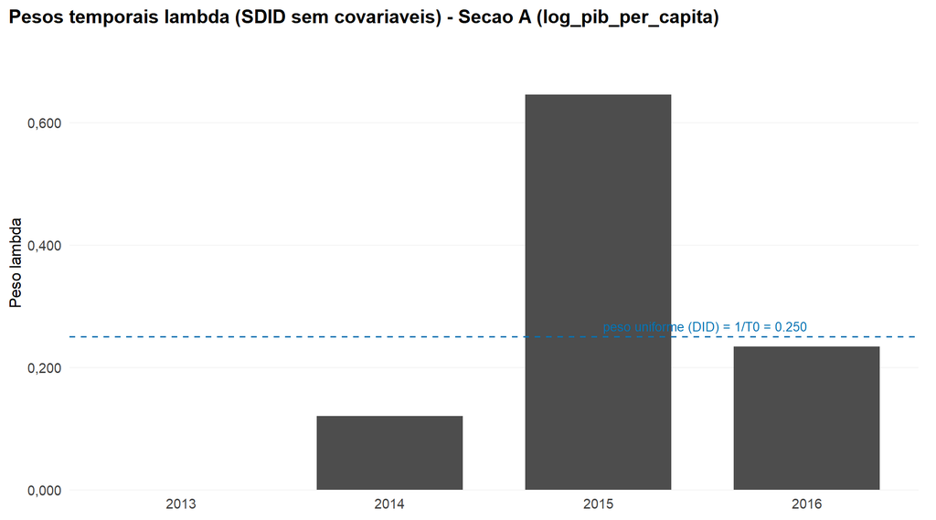

```r
desenhar_pesos_lambda(resultados$A, "A")
```

## 11.4 Event study

### 11.4.1 Efeito ano a ano

```r
tab_event_study(resultados$A)
```

Secao A - event study ano a ano (sem_cov)

| Secao | Variavel | Covariaveis | Ano | Periodo | Efeito_estimado | Erro_Padrao | Estatistica_t | P_valor | IC95_Inferior | IC95_Superior | Banda_placebo_Inferior | Banda_placebo_Superior | Significancia |
| --- | --- | --- | --- | --- | --- | --- | --- | --- | --- | --- | --- | --- | --- |
| A | log_pib_per_capita | sem_cov | 2013 | Pre | -0.0021 | 0.0264 | -0.081 | 0.884 | -0.0540 | 0.0497 | -0.0551 | 0.0634 |  |
| A | log_pib_per_capita | sem_cov | 2014 | Pre | 0.0047 | 0.0376 | 0.125 | 0.768 | -0.0690 | 0.0784 | -0.0346 | 0.0597 |  |
| A | log_pib_per_capita | sem_cov | 2015 | Pre | -0.0023 | 0.0108 | -0.212 | 0.710 | -0.0235 | 0.0189 | -0.0141 | 0.0223 |  |
| A | log_pib_per_capita | sem_cov | 2016 | Pre | 0.0039 | 0.0254 | 0.153 | 0.754 | -0.0460 | 0.0538 | -0.0391 | 0.0677 |  |
| A | log_pib_per_capita | sem_cov | 2017 | Pos | -0.0092 | 0.0584 | -0.158 | 0.812 | -0.1238 | 0.1053 | -0.1012 | 0.1516 |  |
| A | log_pib_per_capita | sem_cov | 2018 | Pos | 0.0077 | 0.0937 | 0.082 | 0.899 | -0.1759 | 0.1913 | -0.1347 | 0.1844 |  |
| A | log_pib_per_capita | sem_cov | 2019 | Pos | -0.0153 | 0.0978 | -0.157 | 0.870 | -0.2071 | 0.1765 | -0.1438 | 0.1876 |  |
| A | log_pib_per_capita | sem_cov | 2020 | Pos | -0.0671 | 0.1023 | -0.656 | 0.478 | -0.2677 | 0.1334 | -0.1599 | 0.2286 |  |
| A | log_pib_per_capita | sem_cov | 2021 | Pos | -0.1131 | 0.1673 | -0.676 | 0.449 | -0.4411 | 0.2149 | -0.2948 | 0.3893 |  |
| A | log_pib_per_capita | sem_cov | 2022 | Pos | -0.1911 | 0.1742 | -1.097 | 0.217 | -0.5325 | 0.1503 | -0.2503 | 0.2916 |  |
| A | log_pib_per_capita | sem_cov | 2023 | Pos | -0.1113 | 0.1627 | -0.684 | 0.348 | -0.4303 | 0.2077 | -0.2780 | 0.3272 |  |

### 11.4.2 Testes por permutação

```r
tab_testes_permutacao(resultados$A)
```

Secao A - testes por permutacao

| Teste | Estatistica | P_valor | Significancia |
| --- | --- | --- | --- |
| Pre-tendencia (conjunto, RMSPE pre) | 0.0034 | 0.942 |  |
| Razao RMSPE pos/pre (Abadie 2010) | 28.4118 | 0.072 | * |
| RMSPE pre-tratamento (tratado) | 0.0034 | NA |  |

### 11.4.3 Gráfico

Linhas cinza: gaps de placebo, com cada controle tratado como se fosse a unidade tratada. Faixa cinza: intervalo de 95% da distribuição de placebo. Linha laranja: gap de Florianópolis. Linha vertical: início do tratamento.

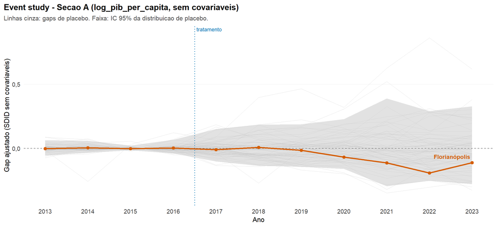

```r
desenhar_event_study(resultados$A, "A")
```

## 11.5 Razão MSPE pós/pré

A razão compara o erro de ajuste do contrafactual depois e antes da concessão. O p-valor é a posição de Florianópolis no ranking das razões de todas as unidades. A coluna ponderada usa os pesos `lambda` do SDID no MSPE pré.

```r
tab_razao_mspe(razao_mspe_secao(resultados$A, "A"), "A")
```

Secao A - razao MSPE pos/pre (Abadie 2010). Tratado = Florianópolis; distribuicao nula com 68 placebo(s).

| Metrica | Valor |
| --- | --- |
| MSPE pre | 0.0000 |
| MSPE pre (ponderado por lambda) | 0.0000 |
| MSPE pos | 0.0095 |
| Razao pos/pre | 807.2331 |
| Razao pos/pre (lambda) | 990.6982 |
| Razao RMSPE | 28.4118 |
| Posto do tratado | 5.0000 |
| P-valor por permutacao | 0.0725 |

```r
tab_ranking_mspe(razao_mspe_secao(resultados$A, "A"), "A")
```

Secao A - maiores razoes MSPE pos/pre

| Posto | Unidade | MSPE_pre | MSPE_pos | Razao | Razao_lambda | Status |
| --- | --- | --- | --- | --- | --- | --- |
| 1 | Itajaí | 0.00004 | 0.07308 | 1710.668 | 6835.690 |  |
| 2 | Serra | 0.00002 | 0.02743 | 1382.044 | 2899.125 |  |
| 3 | Taboão da Serra | 0.00001 | 0.00970 | 1163.869 | 2084.428 |  |
| 4 | Olinda | 0.00002 | 0.02087 | 1071.644 | 1617.997 |  |
| 5 | Florianópolis (tratado) | 0.00001 | 0.00951 | 807.233 | 990.698 |  |
| 6 | Cotia | 0.00001 | 0.00628 | 782.150 | 1678.976 |  |
| 7 | Nova Iguaçu | 0.00004 | 0.02620 | 708.670 | 1756.350 |  |
| 8 | Indaiatuba | 0.00008 | 0.03745 | 443.023 | 696.159 |  |
| 9 | Jaboatão dos Guararapes | 0.00003 | 0.01041 | 383.047 | 642.145 |  |
| 10 | Belford Roxo | 0.00007 | 0.02167 | 331.522 | 585.516 |  |
| 11 | Novo Hamburgo | 0.00001 | 0.00318 | 299.846 | 479.650 |  |
| 12 | Santa Luzia | 0.00008 | 0.02377 | 298.412 | 4978.653 |  |
| 13 | Belo Horizonte | 0.00002 | 0.00427 | 264.590 | 1628.248 |  |
| 14 | Betim | 0.00012 | 0.02908 | 243.537 | 1141.726 |  |
| 15 | São Leopoldo | 0.00004 | 0.00887 | 240.755 | 741.740 |  |

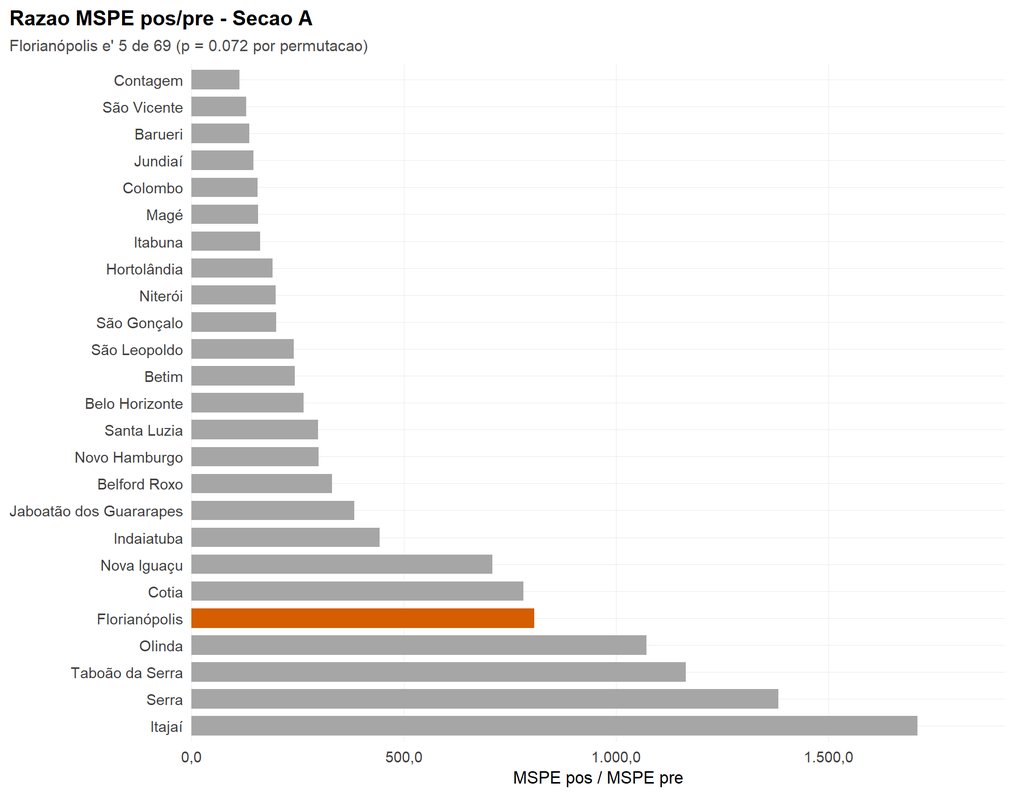

```r
desenhar_razao_mspe(razao_mspe_secao(resultados$A, "A"), "A")
```

## 11.6 Leave-one-out

Variação do ATT ao remover cada controle, em ordem de impacto.

```r
tab_loo(resultados$A)
```

Secao A - leave-one-out sem covariaveis (sem_cov): 15 unidades mais influentes (de 68)

| Covariaveis | Municipio | Peso_omega_original | ATT_original | ATT_sem_unidade | Delta_ATT | Delta_pct |
| --- | --- | --- | --- | --- | --- | --- |
| sem_cov | Mauá | 0.0203 | -0.0714 | -0.0663 | 0.0051 | 7.10 |
| sem_cov | Niterói | 0.0147 | -0.0714 | -0.0672 | 0.0041 | 5.79 |
| sem_cov | Itajaí | 0.0168 | -0.0714 | -0.0675 | 0.0038 | 5.39 |
| sem_cov | Itapevi | 0.0201 | -0.0714 | -0.0750 | -0.0036 | -5.11 |
| sem_cov | Indaiatuba | 0.0158 | -0.0714 | -0.0681 | 0.0032 | 4.52 |
| sem_cov | Blumenau | 0.0182 | -0.0714 | -0.0736 | -0.0023 | -3.21 |
| sem_cov | Juazeiro | 0.0196 | -0.0714 | -0.0691 | 0.0022 | 3.13 |
| sem_cov | Embu das Artes | 0.0186 | -0.0714 | -0.0693 | 0.0021 | 2.93 |
| sem_cov | Serra | 0.0154 | -0.0714 | -0.0693 | 0.0020 | 2.87 |
| sem_cov | São João de Meriti | 0.0144 | -0.0714 | -0.0733 | -0.0019 | -2.73 |
| sem_cov | Nova Iguaçu | 0.0153 | -0.0714 | -0.0732 | -0.0019 | -2.64 |
| sem_cov | Suzano | 0.0231 | -0.0714 | -0.0695 | 0.0019 | 2.62 |
| sem_cov | Duque de Caxias | 0.0227 | -0.0714 | -0.0696 | 0.0018 | 2.51 |
| sem_cov | Olinda | 0.0137 | -0.0714 | -0.0730 | -0.0017 | -2.34 |
| sem_cov | Santa Luzia | 0.0107 | -0.0714 | -0.0697 | 0.0016 | 2.26 |

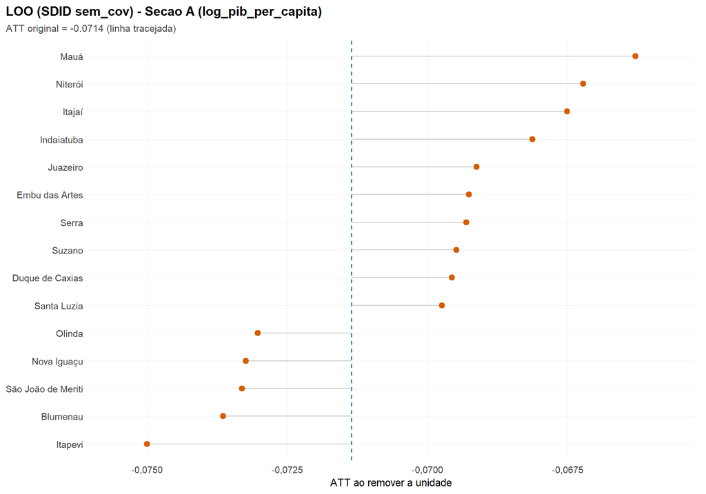

```r
desenhar_loo(resultados$A, "A")
```

## 11.7 Trajetória do ATT com pool escalonado

```r
trajetoria_A <- trajetoria_escalonada_secao("A")
tab_trajetoria_escalonada(trajetoria_A, "A")
```

PIB per capita · anual - ATT por horizonte sob pool escalonado (ainda-nao-tratado)

| Horizonte | N_controles | ATT | Efeito_pct | Erro_Padrao | Estatistica_t | P_valor | Significancia |
| --- | --- | --- | --- | --- | --- | --- | --- |
| 2019 | 90 | -0.0077 | -0.76 | 0.0681 | -0.113 | 0.910 |  |
| 2021 | 75 | -0.0419 | -4.10 | 0.0883 | -0.474 | 0.636 |  |
| 2022 | 68 | -0.0648 | -6.27 | 0.0997 | -0.650 | 0.516 |  |
| 2023 | 68 | -0.0714 | -6.89 | 0.1051 | -0.679 | 0.497 |  |

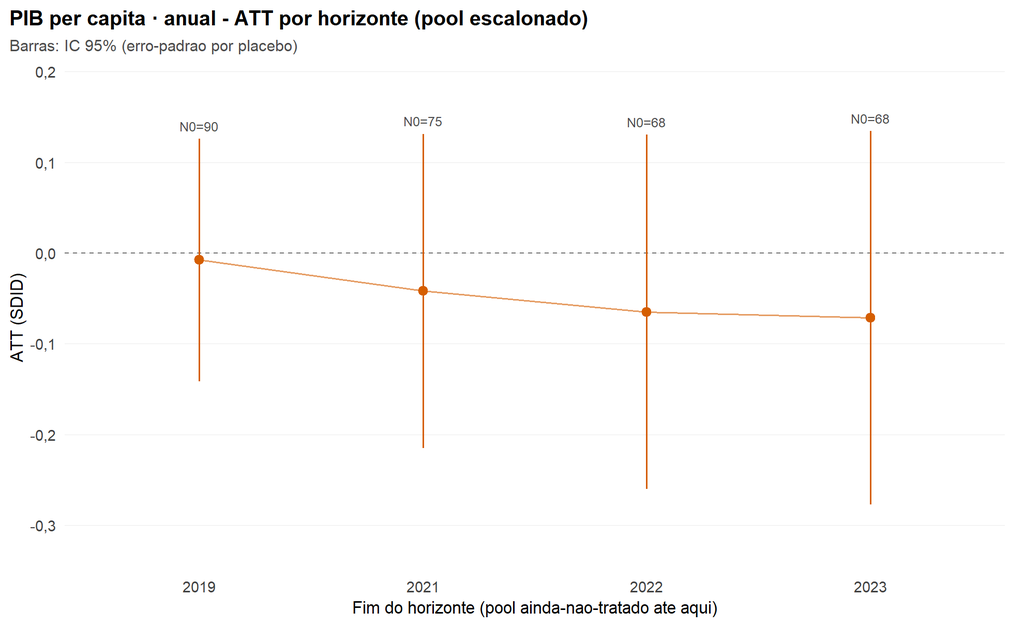

```r
desenhar_trajetoria_escalonada(trajetoria_A, "A")
```

`Delta_ATT` é a diferença em relação ao ATT principal; `Principal_no_IC95` indica se o ATT principal está dentro do IC de 95% de cada ponto.

```r
tab_comparacao_sdid(trajetoria_A, "A")
```

PIB per capita · anual - SDID principal x versoes escalonadas

| Especificacao | N0 | T_pos | ATT | Efeito_pct | Erro_Padrao | Estatistica_t | P_valor | RMSE_pre | Delta_ATT | Sinal_igual | Principal_no_IC95 | Significancia |
| --- | --- | --- | --- | --- | --- | --- | --- | --- | --- | --- | --- | --- |
| Principal (binario) | 68 | 7 | -0.0714 | -6.89 | 0.1051 | -0.679 | 0.497 | 0.0034 | NA | NA | NA |  |
| Escalonado · pool ate 2019 | 90 | 3 | -0.0077 | -0.76 | 0.0681 | -0.113 | 0.910 | 0.0020 | 0.0637 | TRUE | TRUE |  |
| Escalonado · pool ate 2021 | 75 | 5 | -0.0419 | -4.10 | 0.0883 | -0.474 | 0.636 | 0.0028 | 0.0295 | TRUE | TRUE |  |
| Escalonado · pool ate 2022 | 68 | 6 | -0.0648 | -6.27 | 0.0997 | -0.650 | 0.516 | 0.0033 | 0.0066 | TRUE | TRUE |  |
| Escalonado · pool ate 2023 | 68 | 7 | -0.0714 | -6.89 | 0.1051 | -0.679 | 0.497 | 0.0034 | 0.0000 | TRUE | TRUE |  |

## 11.8 Diagramas do `synthdid`

Trajetórias da unidade tratada e do controle sintético, com a seta do efeito estimado, para cada método.

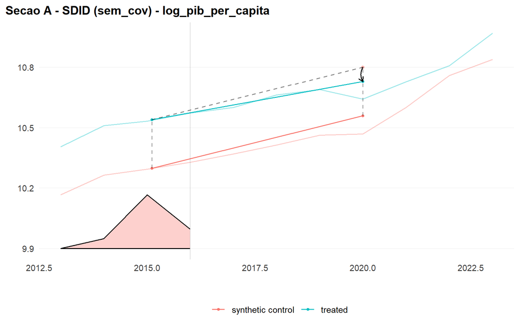

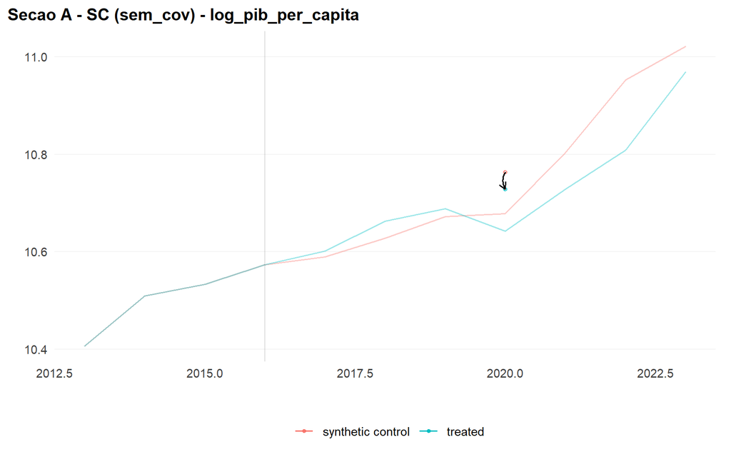

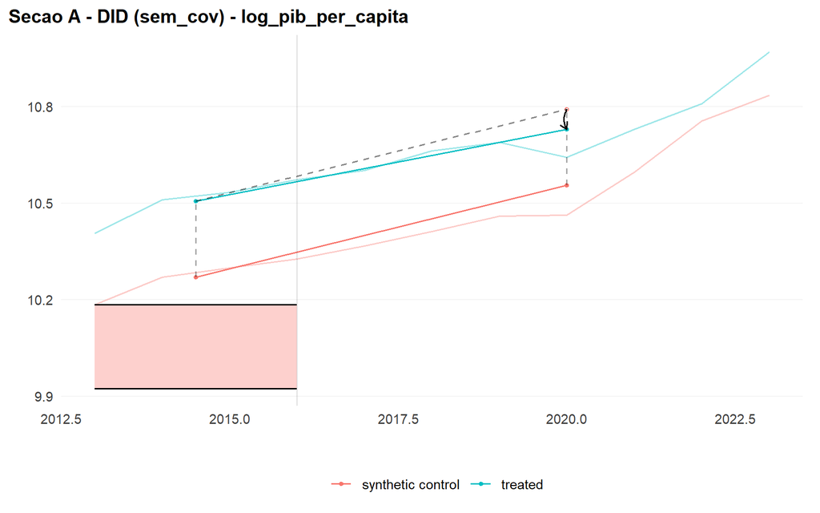

```r
exibir_estimativas_nativas(resultados$A, "A")
```

## 11.9 Robustez: pools restritos

Os cenários abaixo repetem a Seção A com os pools turístico (`A_tur`), tecnológico (`A_tec`) e misto (`A_tectur`). A comparação com a seção principal está em *Comparação entre os pools*.

```r
resultados[["A_tur"]] <- executar_secao("A_tur")
```

```r
resultados[["A_tec"]] <- executar_secao("A_tec")
```

```r
resultados[["A_tectur"]] <- executar_secao("A_tectur")
```

# 12 Seção B — PIB de serviços per capita

Variável dependente: log do PIB de serviços per capita, de 2013 a 2016 (pré) e de 2017 a 2021 (pós). A janela pós termina em 2021, limite de cobertura da RAIS. O efeito é reportado como variação percentual.

```r
resultados$B <- executar_secao("B")
```

## 12.1 Ficha da seção

```r
tab_ficha(resultados$B)
```

Secao B - ficha da estimacao

| Item | Valor |
| --- | --- |
| Variavel dependente | log_pib_servicos_per_capita |
| Especificacao | log_pib_servicos_per_capita ~ tratado:pos |
| Covariaveis | desativadas |
| Conjunto de covariaveis | - |
| Variante dos diagnosticos | SDID sem covariaveis (sem_cov) |
| Janela pre-tratamento | 2013-2016 |
| Janela pos-tratamento | 2017-2021 |
| Ano de tratamento | 2017 |
| Unidade tratada | Florianópolis (4205407) |
| Controles no painel | 68 |
| Escala do efeito | (exp(ATT)-1)*100 - variacao % |
| Event study | estimado (sem_cov) |
| Leave-one-out | estimado (sem_cov) |

## 12.2 ATT por método

```r
tab_resultados(resultados$B)
```

Secao B - ATT por metodo e variante de covariaveis

| Secao | Variavel | Covariaveis | Modelo | Coeficiente | Efeito_pct | Erro_Padrao | Estatistica_t | P_valor | SE_placebo | IC95_quantil | Significancia |
| --- | --- | --- | --- | --- | --- | --- | --- | --- | --- | --- | --- |
| B | log_pib_servicos_per_capita | sem_cov | SDID | -0.0210 | -2.08 | 0.0936 | -0.225 | 0.822 | exaustivo | [-0.233; 0.105] |  |
| B | log_pib_servicos_per_capita | sem_cov | SC | 0.0373 | 3.80 | 0.1148 | 0.325 | 0.745 | exaustivo | [-0.274; 0.202] |  |
| B | log_pib_servicos_per_capita | sem_cov | DID | -0.0174 | -1.73 | 0.1012 | -0.172 | 0.863 | exaustivo | [-0.257; 0.134] |  |
| B | log_pib_servicos_per_capita | event_study | RMSPE_ratio | 10.1340 | NA | NA | NA | 0.304 | NA | NA |  |
| B | log_pib_servicos_per_capita | sem_cov | SDID (SE jackknife via LOO) | -0.0210 | -2.08 | 0.0124 | -1.702 | 0.089 | NA | NA | * |

## 12.3 Pesos do controle sintético

```r
tab_pesos(resultados$B)
```

Secao B - pesos do controle sintetico sem covariaveis (todas as unidades do pool; vetor completo; a coluna soma 1)

| Municipio | Peso_SDID |
| --- | --- |
| Gravataí | 0.0259 |
| Itapevi | 0.0243 |
| Embu das Artes | 0.0218 |
| Jaboatão dos Guararapes | 0.0218 |
| Parnamirim | 0.0217 |
| Aparecida de Goiânia | 0.0216 |
| Olinda | 0.0214 |
| Ananindeua | 0.0213 |
| Blumenau | 0.0209 |
| Vila Velha | 0.0202 |
| Cuiabá | 0.0198 |
| Anápolis | 0.0196 |
| Betim | 0.0194 |
| Paulista | 0.0185 |
| Cariacica | 0.0183 |
| Jundiaí | 0.0182 |
| Caucaia | 0.0182 |
| Cotia | 0.0179 |
| Itajaí | 0.0174 |
| Itaquaquecetuba | 0.0172 |
| Ribeirão das Neves | 0.0171 |
| Diadema | 0.0168 |
| Taboão da Serra | 0.0168 |
| Juazeiro | 0.0166 |
| Santos | 0.0166 |
| São Leopoldo | 0.0164 |
| Chapecó | 0.0164 |
| Maracanaú | 0.0162 |
| Carapicuíba | 0.0159 |
| Osasco | 0.0154 |
| Niterói | 0.0154 |
| Ribeirão Preto | 0.0153 |
| Serra | 0.0152 |
| Suzano | 0.0150 |
| Duque de Caxias | 0.0149 |
| Novo Hamburgo | 0.0145 |
| São Gonçalo | 0.0142 |
| Contagem | 0.0139 |
| Petrópolis | 0.0135 |
| Americana | 0.0135 |
| Sete Lagoas | 0.0134 |
| Colombo | 0.0133 |
| Magé | 0.0133 |
| Indaiatuba | 0.0133 |
| Nova Iguaçu | 0.0133 |
| Viamão | 0.0127 |
| São José do Rio Preto | 0.0126 |
| Belo Horizonte | 0.0125 |
| São Bernardo do Campo | 0.0125 |
| São Vicente | 0.0124 |
| Camaçari | 0.0121 |
| Santo André | 0.0119 |
| Alvorada | 0.0116 |
| Itaboraí | 0.0116 |
| Itabuna | 0.0114 |
| Hortolândia | 0.0108 |
| Barueri | 0.0100 |
| Santa Luzia | 0.0097 |
| Mauá | 0.0094 |
| Natal | 0.0090 |
| Mogi das Cruzes | 0.0088 |
| Maringá | 0.0088 |
| Presidente Prudente | 0.0084 |
| Praia Grande | 0.0075 |
| Sumaré | 0.0070 |
| Belford Roxo | 0.0031 |
| São João de Meriti | 0.0023 |
| Canoas | 0.0023 |

### 12.3.1 Pesos temporais

```r
tab_pesos_lambda(resultados$B)
```

Secao B - pesos temporais (lambda) do SDID sem covariaveis no pre-tratamento (soma = 1)

| Periodo | Peso_lambda |
| --- | --- |
| 2016 | 0.4623 |
| 2015 | 0.3534 |
| 2014 | 0.1843 |
| 2013 | 0.0000 |

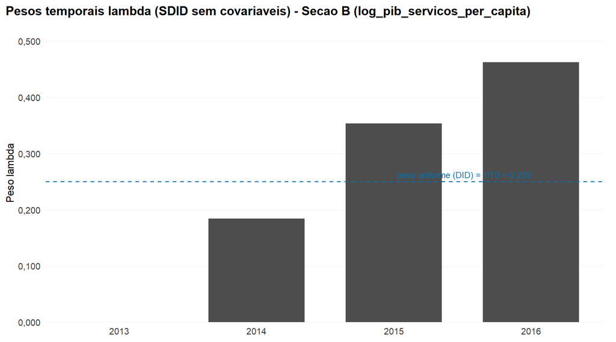

```r
desenhar_pesos_lambda(resultados$B, "B")
```

## 12.4 Event study

### 12.4.1 Efeito ano a ano

```r
tab_event_study(resultados$B)
```

Secao B - event study ano a ano (sem_cov)

| Secao | Variavel | Covariaveis | Ano | Periodo | Efeito_estimado | Erro_Padrao | Estatistica_t | P_valor | IC95_Inferior | IC95_Superior | Banda_placebo_Inferior | Banda_placebo_Superior | Significancia |
| --- | --- | --- | --- | --- | --- | --- | --- | --- | --- | --- | --- | --- | --- |
| B | log_pib_servicos_per_capita | sem_cov | 2013 | Pre | -0.0029 | 0.0357 | -0.082 | 0.826 | -0.0730 | 0.0671 | -0.0674 | 0.0747 |  |
| B | log_pib_servicos_per_capita | sem_cov | 2014 | Pre | 0.0056 | 0.0326 | 0.172 | 0.594 | -0.0584 | 0.0696 | -0.0744 | 0.0358 |  |
| B | log_pib_servicos_per_capita | sem_cov | 2015 | Pre | -0.0042 | 0.0158 | -0.266 | 0.739 | -0.0351 | 0.0268 | -0.0323 | 0.0295 |  |
| B | log_pib_servicos_per_capita | sem_cov | 2016 | Pre | 0.0010 | 0.0174 | 0.056 | 0.884 | -0.0331 | 0.0350 | -0.0279 | 0.0284 |  |
| B | log_pib_servicos_per_capita | sem_cov | 2017 | Pos | 0.0020 | 0.0669 | 0.030 | 0.971 | -0.1291 | 0.1332 | -0.1348 | 0.1097 |  |
| B | log_pib_servicos_per_capita | sem_cov | 2018 | Pos | 0.0178 | 0.0921 | 0.193 | 0.884 | -0.1627 | 0.1982 | -0.1554 | 0.1866 |  |
| B | log_pib_servicos_per_capita | sem_cov | 2019 | Pos | -0.0062 | 0.0972 | -0.064 | 0.986 | -0.1967 | 0.1842 | -0.1476 | 0.2010 |  |
| B | log_pib_servicos_per_capita | sem_cov | 2020 | Pos | -0.0516 | 0.1241 | -0.416 | 0.638 | -0.2948 | 0.1916 | -0.1900 | 0.2802 |  |
| B | log_pib_servicos_per_capita | sem_cov | 2021 | Pos | -0.0671 | 0.1598 | -0.420 | 0.638 | -0.3803 | 0.2461 | -0.2376 | 0.3249 |  |

### 12.4.2 Testes por permutação

```r
tab_testes_permutacao(resultados$B)
```

Secao B - testes por permutacao

| Teste | Estatistica | P_valor | Significancia |
| --- | --- | --- | --- |
| Pre-tendencia (conjunto, RMSPE pre) | 0.0038 | 0.899 |  |
| Razao RMSPE pos/pre (Abadie 2010) | 10.1340 | 0.304 |  |
| RMSPE pre-tratamento (tratado) | 0.0038 | NA |  |

### 12.4.3 Gráfico

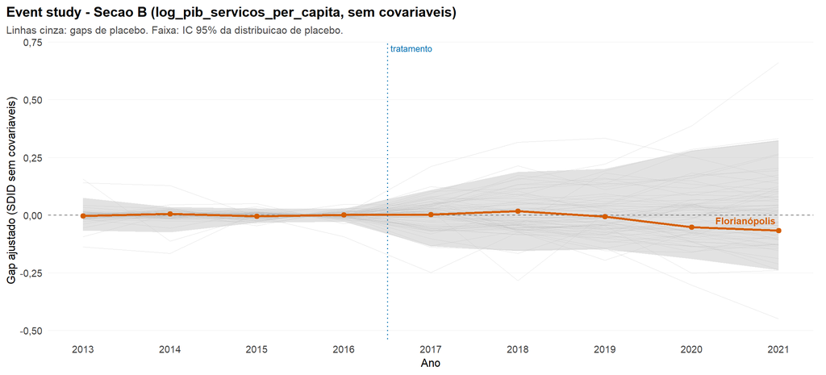

```r
desenhar_event_study(resultados$B, "B")
```

## 12.5 Razão MSPE pós/pré

```r
tab_razao_mspe(razao_mspe_secao(resultados$B, "B"), "B")
```

Secao B - razao MSPE pos/pre (Abadie 2010). Tratado = Florianópolis; distribuicao nula com 68 placebo(s).

| Metrica | Valor |
| --- | --- |
| MSPE pre | 0.0000 |
| MSPE pre (ponderado por lambda) | 0.0000 |
| MSPE pos | 0.0015 |
| Razao pos/pre | 102.6986 |
| Razao pos/pre (lambda) | 120.9109 |
| Razao RMSPE | 10.1340 |
| Posto do tratado | 21.0000 |
| P-valor por permutacao | 0.3043 |

```r
tab_ranking_mspe(razao_mspe_secao(resultados$B, "B"), "B")
```

Secao B - maiores razoes MSPE pos/pre

| Posto | Unidade | MSPE_pre | MSPE_pos | Razao | Razao_lambda | Status |
| --- | --- | --- | --- | --- | --- | --- |
| 1 | Itajaí | 0.00002 | 0.13317 | 6481.705 | 8207.440 |  |
| 2 | Indaiatuba | 0.00001 | 0.04466 | 3050.027 | 13272.207 |  |
| 3 | Colombo | 0.00001 | 0.02590 | 2086.303 | 3560.708 |  |
| 4 | Chapecó | 0.00001 | 0.01471 | 1098.079 | 982.179 |  |
| 5 | Serra | 0.00003 | 0.02680 | 900.195 | 816.941 |  |
| 6 | São Leopoldo | 0.00003 | 0.01318 | 508.193 | 526.992 |  |
| 7 | Hortolândia | 0.00010 | 0.04746 | 456.236 | 655.002 |  |
| 8 | Belo Horizonte | 0.00001 | 0.00356 | 341.118 | 2355.679 |  |
| 9 | Nova Iguaçu | 0.00005 | 0.01416 | 264.379 | 650.329 |  |
| 10 | Contagem | 0.00001 | 0.00307 | 246.339 | 3434.802 |  |
| 11 | São Gonçalo | 0.00004 | 0.00981 | 245.863 | 282.093 |  |
| 12 | Magé | 0.00001 | 0.00246 | 228.409 | 448.531 |  |
| 13 | Niterói | 0.00008 | 0.01501 | 187.370 | 199.244 |  |
| 14 | São Vicente | 0.00002 | 0.00324 | 176.740 | 339.769 |  |
| 15 | Itabuna | 0.00004 | 0.00664 | 172.725 | 126.414 |  |
| 21 | Florianópolis (tratado) | 0.00001 | 0.00150 | 102.699 | 120.911 |  |

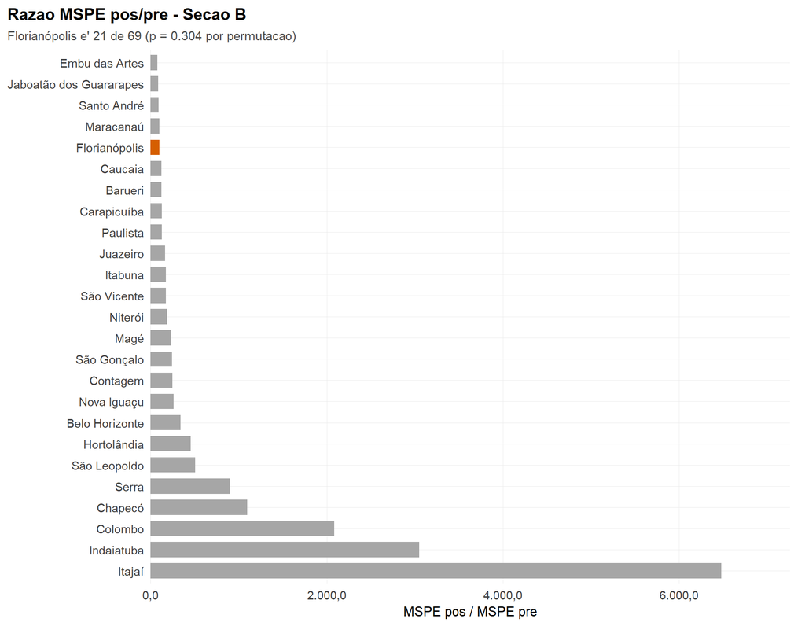

```r
desenhar_razao_mspe(razao_mspe_secao(resultados$B, "B"), "B")
```

## 12.6 Leave-one-out

```r
tab_loo(resultados$B)
```

Secao B - leave-one-out sem covariaveis (sem_cov): 15 unidades mais influentes (de 68)

| Covariaveis | Municipio | Peso_omega_original | ATT_original | ATT_sem_unidade | Delta_ATT | Delta_pct |
| --- | --- | --- | --- | --- | --- | --- |
| sem_cov | Itajaí | 0.0174 | -0.021 | -0.0156 | 0.0054 | 25.64 |
| sem_cov | Embu das Artes | 0.0218 | -0.021 | -0.0162 | 0.0048 | 22.84 |
| sem_cov | Itapevi | 0.0243 | -0.021 | -0.0241 | -0.0031 | -14.58 |
| sem_cov | Jaboatão dos Guararapes | 0.0218 | -0.021 | -0.0240 | -0.0030 | -14.03 |
| sem_cov | Olinda | 0.0214 | -0.021 | -0.0240 | -0.0029 | -14.03 |
| sem_cov | Indaiatuba | 0.0133 | -0.021 | -0.0184 | 0.0026 | 12.29 |
| sem_cov | Betim | 0.0194 | -0.021 | -0.0236 | -0.0026 | -12.26 |
| sem_cov | Juazeiro | 0.0166 | -0.021 | -0.0186 | 0.0024 | 11.59 |
| sem_cov | Aparecida de Goiânia | 0.0216 | -0.021 | -0.0233 | -0.0023 | -10.86 |
| sem_cov | Serra | 0.0152 | -0.021 | -0.0190 | 0.0020 | 9.51 |
| sem_cov | Maracanaú | 0.0162 | -0.021 | -0.0191 | 0.0019 | 9.25 |
| sem_cov | Cariacica | 0.0183 | -0.021 | -0.0194 | 0.0017 | 7.96 |
| sem_cov | Chapecó | 0.0164 | -0.021 | -0.0194 | 0.0017 | 7.95 |
| sem_cov | Colombo | 0.0133 | -0.021 | -0.0227 | -0.0016 | -7.75 |
| sem_cov | Blumenau | 0.0209 | -0.021 | -0.0226 | -0.0016 | -7.70 |

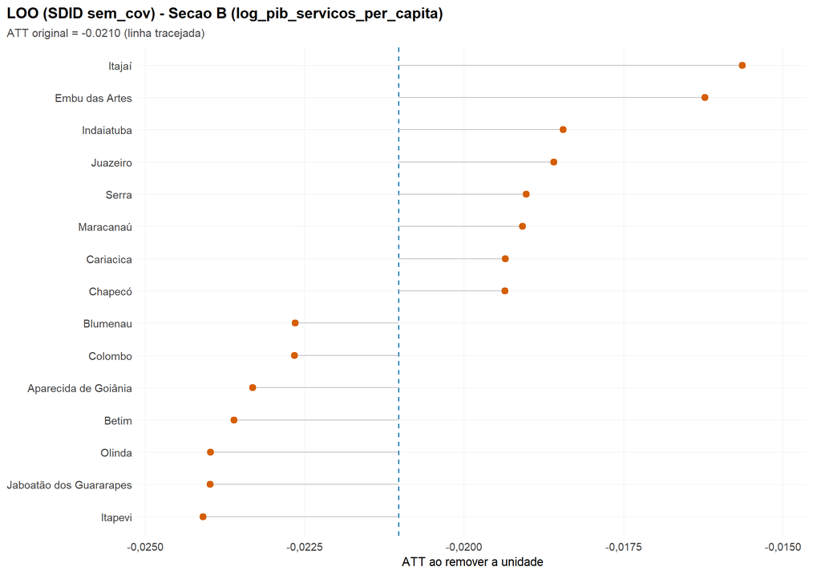

```r
desenhar_loo(resultados$B, "B")
```

## 12.7 Trajetória do ATT com pool escalonado

```r
trajetoria_B <- trajetoria_escalonada_secao("B")
tab_trajetoria_escalonada(trajetoria_B, "B")
```

PIB servicos p.c. · anual - ATT por horizonte sob pool escalonado (ainda-nao-tratado)

| Horizonte | N_controles | ATT | Efeito_pct | Erro_Padrao | Estatistica_t | P_valor | Significancia |
| --- | --- | --- | --- | --- | --- | --- | --- |
| 2019 | 90 | 0.0067 | 0.67 | 0.0670 | 0.099 | 0.921 |  |
| 2021 | 75 | -0.0199 | -1.97 | 0.0901 | -0.221 | 0.825 |  |

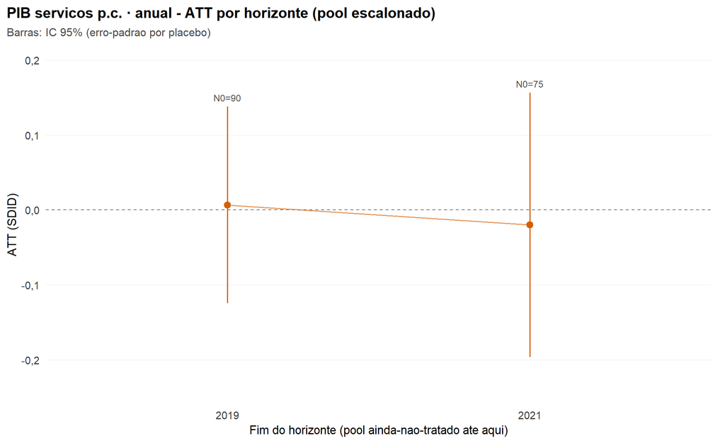

```r
desenhar_trajetoria_escalonada(trajetoria_B, "B")
```

```r
tab_comparacao_sdid(trajetoria_B, "B")
```

PIB servicos p.c. · anual - SDID principal x versoes escalonadas

| Especificacao | N0 | T_pos | ATT | Efeito_pct | Erro_Padrao | Estatistica_t | P_valor | RMSE_pre | Delta_ATT | Sinal_igual | Principal_no_IC95 | Significancia |
| --- | --- | --- | --- | --- | --- | --- | --- | --- | --- | --- | --- | --- |
| Principal (binario) | 68 | 5 | -0.0210 | -2.08 | 0.0936 | -0.225 | 0.822 | 0.0038 | NA | NA | NA |  |
| Escalonado · pool ate 2019 | 90 | 3 | 0.0067 | 0.67 | 0.0670 | 0.099 | 0.921 | 0.0022 | 0.0277 | FALSE | TRUE |  |
| Escalonado · pool ate 2021 | 75 | 5 | -0.0199 | -1.97 | 0.0901 | -0.221 | 0.825 | 0.0035 | 0.0011 | TRUE | TRUE |  |

## 12.8 Diagramas do `synthdid`

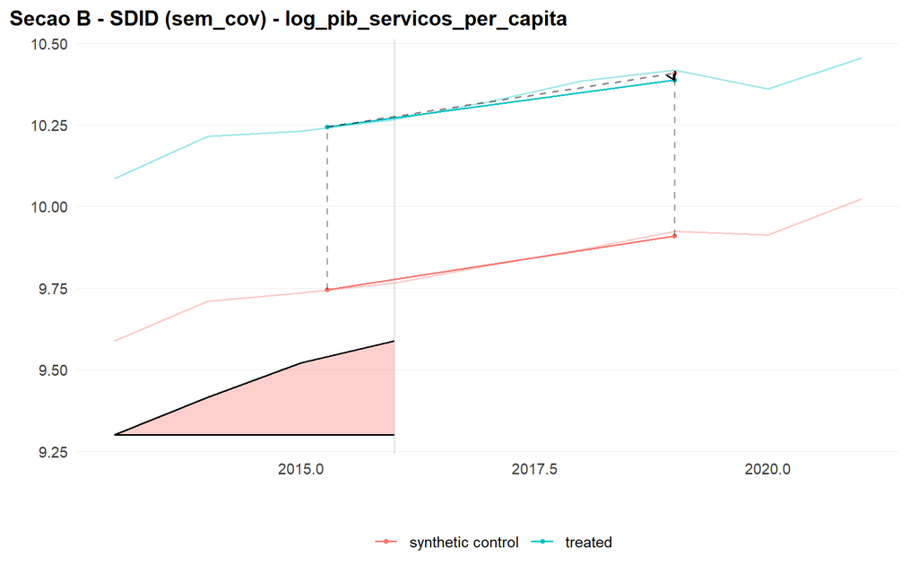

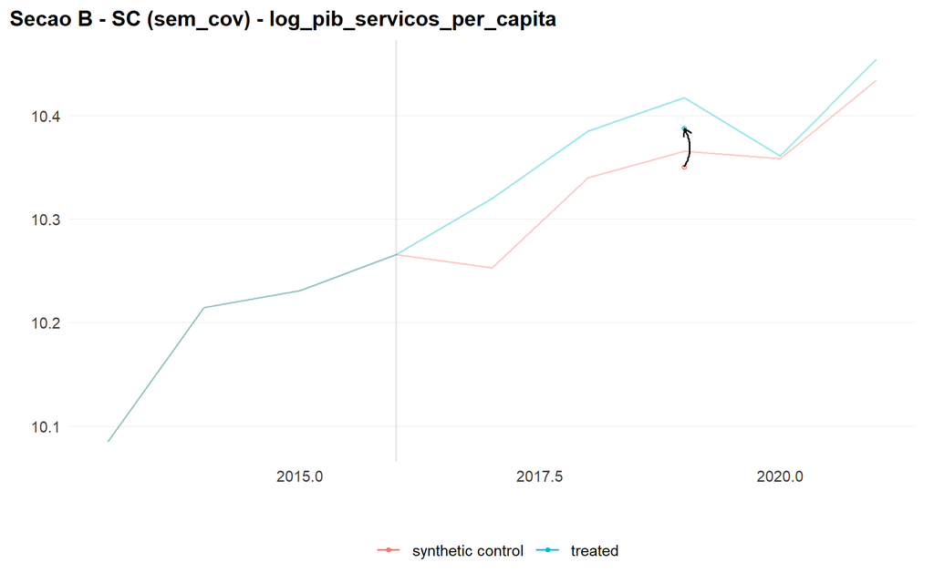

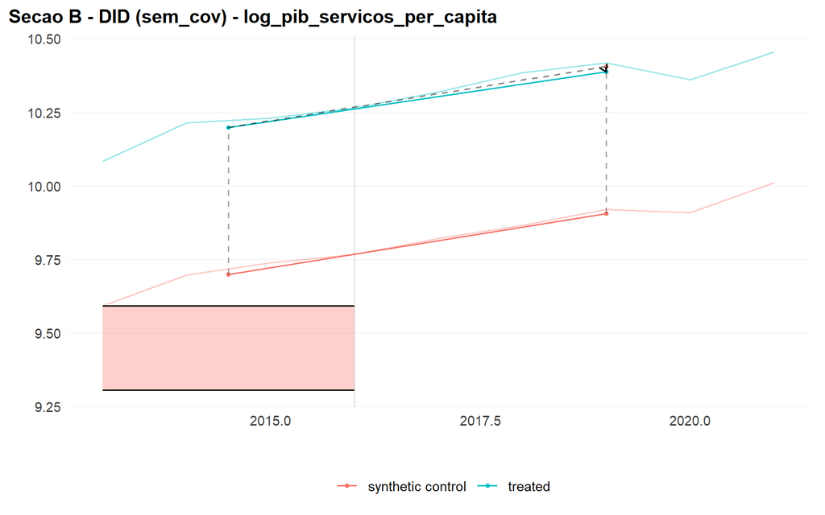

```r
exibir_estimativas_nativas(resultados$B, "B")
```

## 12.9 Robustez: pools restritos

```r
resultados[["B_tur"]] <- executar_secao("B_tur")
```

```r
resultados[["B_tec"]] <- executar_secao("B_tec")
```

```r
resultados[["B_tectur"]] <- executar_secao("B_tectur")
```

# 13 Comparação entre os pools

Para cada pool restrito, a primeira tabela compara o ATT com o da seção principal. `p_minimo` é o menor p-valor atingível com o N0 daquele pool, $1/(N_0+1)$: com menos controles, o teste tem menos poder.

A segunda tabela verifica se os pesos `omega` da seção principal já concentravam peso em municípios de alta densidade setorial (`Razao_omega_pool` > 1). Nesse caso, a restrição apenas confirma o resultado e o ATT deve mudar pouco. Se os pesos não concentravam e o ATT muda muito, os doadores escolhidos pelo pool completo eram estruturalmente diferentes de Florianópolis nessa dimensão. `Peso_coberto` é a soma dos pesos considerados; valores bem abaixo de 1 tornam a razão apenas indicativa.

## 13.1 Pool turístico

```r
tab_comparacao_turismo()
```

ATT (SDID, sem covariaveis): secao-mae e cenario com pool restrito por intensidade turistica

| Secao | Especificacao | Id | N0 | p_minimo | ATT | Efeito_pct | Erro_Padrao | P_valor |
| --- | --- | --- | --- | --- | --- | --- | --- | --- |
| A | mae (pool geral) | A | 68 | 0.0145 | -0.0714 | -6.8870 | 0.1051 | 0.4972 |
| A | cenario (pool turistico) | A_tur | 22 | 0.0435 | -0.0771 | -7.4171 | 0.1498 | 0.6069 |
| B | mae (pool geral) | B | 68 | 0.0145 | -0.0210 | -2.0808 | 0.0936 | 0.8223 |
| B | cenario (pool turistico) | B_tur | 22 | 0.0435 | -0.0414 | -4.0571 | 0.1157 | 0.7204 |

```r
tab_omega_turismo()
```

Densidade hoteleira media do pool irrestrito x media ponderada por `omega` da secao-mae. `Razao_omega_pool` > 1 indica que o estimador ja privilegiava doadores mais turisticos. `Peso_coberto` e’ a fracao da massa de omega cuja densidade foi resolvida; e’ interpretavel sozinha apenas quando `Pesos_completos` e’ TRUE.

| Secao | Dens_media_pool | Dens_media_omega | Dens_tratado | Peso_coberto | Pesos_completos | Razao_omega_pool |
| --- | --- | --- | --- | --- | --- | --- |
| A | 1.274 | 1.281 | 8.11 | 1 | TRUE | 1.006 |
| B | 1.274 | 1.261 | 8.11 | 1 | TRUE | 0.990 |

O gráfico abaixo mostra porte e densidade hoteleira dos municípios do pool, com o tamanho dos pontos proporcional ao peso `omega`. A linha tracejada é a média geométrica ponderada da densidade, coerente com o eixo logarítmico e com o caliper definido em log; a tabela acima reporta a média aritmética, que é sempre maior. O arquivo `turismo_dispersao_medias.csv` traz as duas médias.

```r
# Unidades do pool que não sobrevivem ao balanceamento do painel
unidades_fora_do_painel <- function(id, df = df_combinado) {
  r <- if (exists("resultados_todos")) resultados_todos[[id]] else resultados[[id]]
  if (is.null(r) || !(r$var_dep %in% names(df))) return(NULL)

  ini <- r$pre[1]; fim <- r$post[2]
  n_anos <- fim - ini + 1

  d <- df[df$id_municipio %in% secoes[[id]]$pool &
            df$ano >= ini & df$ano <= fim &
            !is.na(df[[r$var_dep]]), c("id_municipio", "ano")]
  obs <- table(as.character(d$id_municipio))

  ids  <- unique(secoes[[id]]$pool)
  anos <- as.integer(obs[as.character(ids)]); anos[is.na(anos)] <- 0L

  data.frame(id_municipio = ids, anos_obs = anos, anos_exigidos = n_anos,
             no_painel = anos == n_anos, stringsAsFactors = FALSE)
}

# Dados do gráfico de dispersão porte x intensidade setorial
dados_dispersao_setorial <- function(id          = "A",
                                     indice      = INDICE_TURISMO,
                                     rotulo_dim  = "hoteleira",
                                     top_n       = 5,
                                     n_extremos  = 2,
                                     janela_pop  = TURISMO_JANELA,
                                     tratado     = MUNICIPIO_TRATADO) {

  if (is.null(indice)) {
    message(sprintf("Sem indice de intensidade %s - dispersao ignorada.", rotulo_dim))
    return(NULL)
  }
  if (!(id %in% names(secoes))) {
    message(sprintf("Secao %s inativa - dispersao ignorada.", id))
    return(NULL)
  }

  r <- if (exists("resultados_todos")) resultados_todos[[id]] else resultados[[id]]

  d <- indice[indice$id_municipio %in% secoes[[id]]$pool &
                !is.na(indice$densidade) & indice$densidade > 0, , drop = FALSE]

  i_trat <- which(d$id_municipio == tratado)
  if (length(i_trat) != 1) {
    warning(sprintf("%s: unidade tratada ausente do indice - dispersao ignorada", id),
            call. = FALSE)
    return(NULL)
  }

  om              <- omega_da_secao(r)
  pesos_completos <- isTRUE(om$completo)
  d$peso <- 0
  if (nrow(om$pesos) > 0) {
    nome <- sub(" \\([^()]*\\)$", "", om$pesos$Municipio)
    amb  <- d$municipio[duplicated(d$municipio)]
    ok   <- !(nome %in% amb)
    if (any(!ok)) {
      warning(sprintf("%s: %d rotulo(s) ambiguo(s) descartado(s) na dispersao",
                      id, sum(!ok)), call. = FALSE)
    }
    idx <- match(nome[ok], d$municipio)
    val <- !is.na(idx)
    d$peso[idx[val]] <- om$pesos$Peso_SDID[ok][val]
    if (!pesos_completos) {
      n_zero <- sum(d$peso == 0) - 1L
      if (n_zero > 0) {
        message(sprintf(paste("  Secao %s: pesos vindos de cache TRUNCADO em %s -",
                              "%d controle(s) entram com peso 0 por corte de",
                              "exibicao, e nao por omega nulo"),
                        id, format(LIMIAR_PESO_EXIBIDO), n_zero))
      }
    }
  } else {
    message(sprintf("  Secao %s: sem pesos omega - todos os pontos com tamanho uniforme", id))
  }

  bal <- unidades_fora_do_painel(id)
  d$no_painel <- TRUE
  d$anos_obs  <- NA_integer_
  if (!is.null(bal)) {
    i <- match(d$id_municipio, bal$id_municipio)
    d$no_painel <- ifelse(is.na(i), TRUE, bal$no_painel[i])
    d$anos_obs  <- bal$anos_obs[i]
    fora <- d$municipio[!d$no_painel & d$id_municipio != tratado]
    if (length(fora) > 0) {
      message(sprintf("  Secao %s: %d elegivel(is) fora do painel (serie incompleta de %s): %s",
                      id, length(fora), r$var_dep, paste(fora, collapse = ", ")))
    }
  }

  d$log_pop  <- log(d$pop_pre)
  d$tratado  <- seq_len(nrow(d)) == i_trat
  ctrl <- d[-i_trat, , drop = FALSE]

  mu <- mean(ctrl$log_dens, na.rm = TRUE)
  dp <- stats::sd(ctrl$log_dens, na.rm = TRUE)

  i_ctrl  <- setdiff(seq_len(nrow(d)), i_trat)
  ordem_p <- i_ctrl[order(-d$peso[i_ctrl])]
  i_peso  <- utils::head(ordem_p[d$peso[ordem_p] > 0], top_n)
  n_ext   <- max(0L, min(as.integer(n_extremos), length(i_ctrl)))
  i_alto  <- if (n_ext > 0) utils::head(i_ctrl[order(-d$log_dens[i_ctrl])], n_ext) else integer(0)
  i_baixo <- if (n_ext > 0) utils::head(i_ctrl[order( d$log_dens[i_ctrl])], n_ext) else integer(0)
  i_fora  <- i_ctrl[!d$no_painel[i_ctrl]]

  d$motivo_rotulo <- NA_character_
  d$motivo_rotulo[i_baixo] <- "extremo inferior"
  d$motivo_rotulo[i_alto]  <- "extremo superior"
  d$motivo_rotulo[i_fora]  <- "fora do painel"
  d$motivo_rotulo[i_peso]  <- "maior peso omega"
  d$motivo_rotulo[i_trat]  <- "unidade tratada"
  d$rotular <- !is.na(d$motivo_rotulo)

  w <- ctrl$peso
  w[!is.finite(w) | w < 0] <- 0
  usa_omega <- sum(w) > 0
  media_omega <- if (usa_omega) {
    exp(sum(w * ctrl$log_dens, na.rm = TRUE) / sum(w))
  } else {
    exp(mean(ctrl$log_dens, na.rm = TRUE))
  }
  media_omega_arit <- if (usa_omega) {
    sum(w * ctrl$densidade, na.rm = TRUE) / sum(w)
  } else {
    mean(ctrl$densidade, na.rm = TRUE)
  }

  list(
    d          = d,
    i_trat     = i_trat,
    id         = id,
    rotulo_dim = rotulo_dim,
    top_n      = top_n,
    n_extremos = n_ext,
    janela_pop = janela_pop,
    z_trat     = (d$log_dens[i_trat] - mu) / dp,
    media_ctrl       = exp(mean(ctrl$log_dens, na.rm = TRUE)),
    media_omega      = media_omega,
    media_omega_arit = media_omega_arit,
    usa_omega        = usa_omega,
    pesos_completos  = pesos_completos,
    p_max      = max(w, na.rm = TRUE),
    n_ctrl     = nrow(ctrl),
    n_painel   = if (!is.null(r) && !is.null(r$n_controles)) r$n_controles else NA_integer_,
    tabela     = d[order(-d$peso), c("id_municipio", "municipio", "pop_pre",
                                     "estoque_cnae", "densidade", "log_dens",
                                     "peso", "anos_obs", "no_painel",
                                     "motivo_rotulo")],
    resumo = data.frame(
      Secao                   = id,
      Dimensao                = rotulo_dim,
      Densidade_tratado       = d$densidade[i_trat],
      Media_geometrica_omega  = media_omega,
      Media_aritmetica_omega  = media_omega_arit,
      Media_geometrica_simples = exp(mean(ctrl$log_dens, na.rm = TRUE)),
      Razao_arit_geo          = media_omega_arit / media_omega,
      Var_pond_log_densidade  = if (usa_omega)
        sum(w * (ctrl$log_dens - log(media_omega))^2, na.rm = TRUE) / sum(w)
        else stats::var(ctrl$log_dens, na.rm = TRUE),
      Z_tratado               = (d$log_dens[i_trat] - mu) / dp,
      Usa_omega               = usa_omega,
      Peso_coberto            = sum(w),
      Pesos_completos         = pesos_completos,
      stringsAsFactors        = FALSE)
  )
}
```

```r
# Gráfico de dispersão porte x intensidade setorial
plot_dispersao_setorial <- function(dd,
                                    rotulo_y = "Vínculos por mil hab.",
                                    log_y    = TRUE) {
  if (is.null(dd)) return(placeholder_grafico("Dispersao setorial indisponivel"))

  d    <- dd$d
  trat <- d[dd$i_trat, , drop = FALSE]
  ctrl <- d[-dd$i_trat, , drop = FALSE]
  dentro <- ctrl[ctrl$no_painel, , drop = FALSE]
  fora   <- ctrl[!ctrl$no_painel, , drop = FALSE]

  usa_peso <- isTRUE(dd$usa_omega) && is.finite(dd$p_max) && dd$p_max > 0

  nulos <- dentro[0, , drop = FALSE]
  if (usa_peso) {
    sem_peso <- !is.finite(dentro$peso) | dentro$peso <= 0
    nulos    <- dentro[ sem_peso, , drop = FALSE]
    dentro   <- dentro[!sem_peso, , drop = FALSE]
  }

  nota_nulos <- if (nrow(nulos) == 0) {
    ""
  } else if (isTRUE(dd$pesos_completos)) {
    sprintf(" | vazado (%d): omega nulo", nrow(nulos))
  } else {
    sprintf(" | vazado (%d): omega <= %s, truncado em cache", nrow(nulos),
            formatC(LIMIAR_PESO_EXIBIDO, format = "f", digits = 2,
                    decimal.mark = ","))
  }

  p <- ggplot2::ggplot() +
    ggplot2::geom_hline(yintercept = dd$media_omega, colour = "grey40",
                        linetype = "dashed", linewidth = 0.4)

  p <- p + if (usa_peso) {
    ggplot2::geom_point(data = dentro,
                        ggplot2::aes(x = log_pop, y = densidade, size = peso),
                        shape = 21, fill = cor_de("controle"), colour = "grey25",
                        alpha = 0.55, stroke = 0.3)
  } else {
    ggplot2::geom_point(data = dentro,
                        ggplot2::aes(x = log_pop, y = densidade),
                        shape = 21, size = 2.6, fill = cor_de("controle"),
                        colour = "grey25", alpha = 0.55, stroke = 0.3)
  }

  if (nrow(nulos) > 0) {
    p <- p + ggplot2::geom_point(data = nulos,
                                 ggplot2::aes(x = log_pop, y = densidade),
                                 shape = 21, size = 1.9, fill = NA,
                                 colour = "grey45", stroke = 0.5)
  }

  if (nrow(fora) > 0) {
    p <- p + ggplot2::geom_point(data = fora,
                                 ggplot2::aes(x = log_pop, y = densidade),
                                 shape = 4, size = 2.2, stroke = 0.9,
                                 colour = cor_de("descartado"))
  }

  p <- p +
    ggplot2::geom_point(data = trat,
                        ggplot2::aes(x = log_pop, y = densidade),
                        shape = 23, size = 4, fill = cor_de("tratado"),
                        colour = "grey15", stroke = 0.6)

  if (usa_peso) {
    qp <- quebras_peso_omega(dentro$peso)
    p <- p + ggplot2::scale_size_area(
      name = "Peso omega", max_size = 7,
      breaks = qp, labels = formato_peso_omega(qp))
  }

  rot   <- d[d$rotular, , drop = FALSE]
  rot_t <- rot[rot$tratado, , drop = FALSE]
  rot_c <- rot[!rot$tratado, , drop = FALSE]

  camada_rotulo <- function(dados, cor, tamanho, face) {
    if (nrow(dados) == 0) return(NULL)
    if (TEM_GGREPEL) {
      ggrepel::geom_text_repel(
        data = dados,
        ggplot2::aes(x = log_pop, y = densidade, label = municipio),
        size = tamanho, colour = cor, fontface = face,
        min.segment.length = 0, segment.size = 0.2, segment.colour = "grey70",
        box.padding = 0.35, max.overlaps = Inf, seed = 1L)
    } else {
      ggplot2::geom_text(
        data = dados,
        ggplot2::aes(x = log_pop, y = densidade, label = municipio),
        size = tamanho, colour = cor, fontface = face,
        hjust = -0.12, vjust = -0.4, check_overlap = TRUE)
    }
  }

  p <- p +
    camada_rotulo(rot_c[rot_c$no_painel, , drop = FALSE], "grey20", 2.7, "plain") +
    camada_rotulo(rot_c[!rot_c$no_painel, , drop = FALSE],
                  cor_de("descartado"), 2.7, "plain") +
    camada_rotulo(rot_t, cor_de("tratado"), 3.2, "bold")

  y_texto <- if (isTRUE(log_y)) dd$media_omega * 1.15 else
    dd$media_omega + 0.06 * diff(range(d$densidade, na.rm = TRUE))
  p <- p + ggplot2::annotate(
    "text", x = Inf, y = y_texto,
    hjust = 1.02, size = 2.9, colour = "grey30",
    label = sprintf(
      if (isTRUE(dd$usa_omega))
        "Média geométrica dos doadores, ponderada por omega: %s"
      else "Média geométrica dos doadores (sem pesos omega): %s",
      formato_br(max(2L, 2L - as.integer(floor(log10(abs(dd$media_omega))))))(
        dd$media_omega)))

  if (isTRUE(log_y)) {
    p <- p + ggplot2::scale_y_log10(breaks = quebras_log125(d$densidade),
                                    labels = formato_br_log())
  } else {
    p <- p + ggplot2::scale_y_continuous(labels = formato_br(1))
  }

  p +
    escala_x_populacao(d$log_pop, janela = dd$janela_pop) +
    ggplot2::labs(
      title = sprintf("Seção %s: porte x intensidade %s", dd$id, dd$rotulo_dim),
      subtitle = sprintf(
        paste0("%s (losango) tem %.2f por mil hab., z = %+.2f nos doadores | ",
               "%d elegiveis%s\nRotulos: tratado + %d maiores pesos + %d extremos ",
               "de cada ponta + fora do painel (x)%s"),
        trat$municipio, trat$densidade, dd$z_trat, dd$n_ctrl,
        if (is.na(dd$n_painel)) "" else sprintf(", N0 = %d no painel", dd$n_painel),
        dd$top_n, dd$n_extremos, nota_nulos),
      y = rotulo_y) +
    tema_tcc(grade = "ambas") +
    ggplot2::theme(
      legend.position   = "right",
      legend.title      = ggplot2::element_text(size = 9, colour = "grey25"),
      legend.text       = ggplot2::element_text(size = 8, colour = "grey30"),
      legend.background = ggplot2::element_blank())
}

# Exporta o gráfico de dispersão e suas tabelas
exportar_dispersao_setorial <- function(prefixo, rotulo_y = "Vínculos por mil hab.",
                                        log_y = TRUE, ...) {
  dd <- dados_dispersao_setorial(...)
  if (is.null(dd)) return(invisible(NULL))

  p <- plot_dispersao_setorial(dd, rotulo_y = rotulo_y, log_y = log_y)
  print(p)

  salvar_grafico(file.path(DIR_SAIDA, sprintf("%s_dispersao_porte_densidade.png", prefixo)),
                 1100, 700, function() p)
  exportar_csv(dd$tabela,
               file.path(DIR_SAIDA, sprintf("%s_dispersao_porte_densidade.csv", prefixo)),
               sprintf("Dispersao porte x densidade (%s)", prefixo))
  exportar_csv(dd$resumo,
               file.path(DIR_SAIDA, sprintf("%s_dispersao_medias.csv", prefixo)),
               sprintf("Medias de referencia da dispersao (%s)", prefixo))
  message(sprintf(paste("  %s: media geometrica ponderada = %.4f |",
                        "aritmetica (tab. omega) = %.4f | razao = %.2f"),
                  prefixo, dd$resumo$Media_geometrica_omega,
                  dd$resumo$Media_aritmetica_omega, dd$resumo$Razao_arit_geo))
  invisible(dd$tabela)
}
```

```r
# Gráficos de dispersão porte x intensidade setorial (exportados para outputs/)
tab_dispersao_turismo <- exportar_dispersao_setorial(
  "turismo", id = "A", indice = INDICE_TURISMO,
  rotulo_dim = "hoteleira",
  rotulo_y   = "Vínculos em alojamento (CNAE 55) por mil hab.",
  top_n = 5, n_extremos = 2, janela_pop = TURISMO_JANELA)
```

[figure not shown]

```r
tab_dispersao_tecnologia <- exportar_dispersao_setorial(
  "tecnologia", id = "A", indice = INDICE_TECNOLOGIA,
  rotulo_dim = "tecnológica",
  rotulo_y   = "Vínculos em TI e serviços de informação (CNAE 62+63) por mil hab.",
  top_n = 5, n_extremos = 2, janela_pop = TECNOLOGIA_JANELA)
```

[figure not shown]

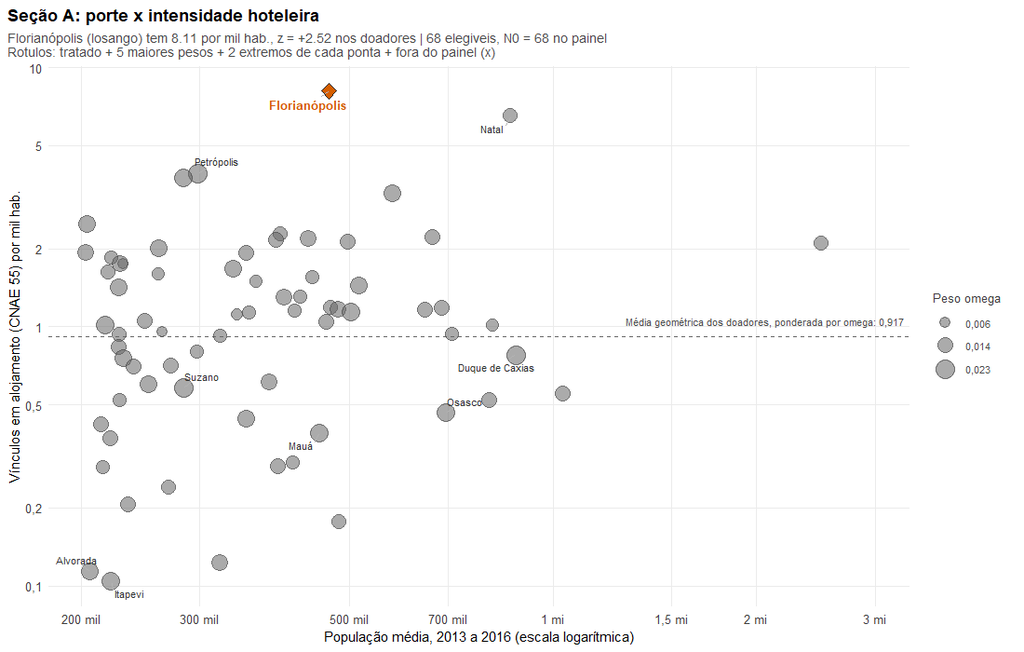

```r
knitr::include_graphics(file.path(DIR_SAIDA, "turismo_dispersao_porte_densidade.png"))
```

## 13.2 Pool tecnológico

```r
tab_comparacao_tecnologia()
```

ATT (SDID, sem covariaveis): secao-mae e cenario com pool restrito por intensidade tecnologica

| Secao | Especificacao | Id | N0 | p_minimo | ATT | Efeito_pct | Erro_Padrao | P_valor |
| --- | --- | --- | --- | --- | --- | --- | --- | --- |
| A | mae (pool geral) | A | 68 | 0.0145 | -0.0714 | -6.8870 | 0.1051 | 0.4972 |
| A | cenario (pool tecnologico) | A_tec | 24 | 0.0400 | -0.0741 | -7.1465 | 0.1405 | 0.5977 |
| B | mae (pool geral) | B | 68 | 0.0145 | -0.0210 | -2.0808 | 0.0936 | 0.8223 |
| B | cenario (pool tecnologico) | B_tec | 24 | 0.0400 | -0.0185 | -1.8283 | 0.0818 | 0.8216 |

```r
tab_omega_tecnologia()
```

Densidade tecnologica media do pool irrestrito x media ponderada por `omega` da secao-mae. `Razao_omega_pool` > 1 indica que o estimador ja privilegiava doadores mais tecnologicos. `Peso_coberto` e’ a fracao da massa de omega cuja densidade foi resolvida; e’ interpretavel sozinha apenas quando `Pesos_completos` e’ TRUE.

| Secao | Dens_media_pool | Dens_media_omega | Dens_tratado | Peso_coberto | Pesos_completos | Razao_omega_pool |
| --- | --- | --- | --- | --- | --- | --- |
| A | 3.266 | 2.824 | 36.682 | 1 | TRUE | 0.865 |
| B | 3.266 | 3.016 | 36.682 | 1 | TRUE | 0.923 |

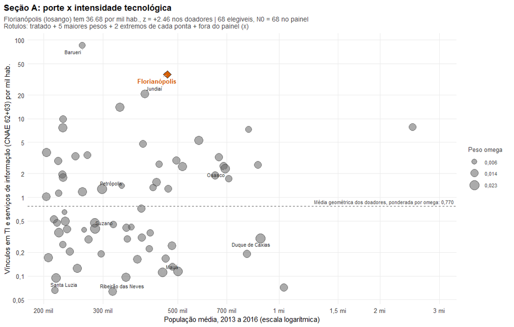

```r
knitr::include_graphics(file.path(DIR_SAIDA, "tecnologia_dispersao_porte_densidade.png"))
```

## 13.3 Pool misto

```r
tab_comparacao_misto()
```

ATT (SDID, sem covariaveis): secao-mae e cenario com pool restrito nas duas dimensoes (turistica e tecnologica)

| Secao | Especificacao | Id | N0 | p_minimo | ATT | Efeito_pct | Erro_Padrao | P_valor |
| --- | --- | --- | --- | --- | --- | --- | --- | --- |
| A | mae (pool geral) | A | 68 | 0.0145 | -0.0714 | -6.8870 | 0.1051 | 0.4972 |
| A | cenario (pool misto) | A_tectur | 19 | 0.0500 | -0.0994 | -9.4616 | 0.1334 | 0.4561 |
| B | mae (pool geral) | B | 68 | 0.0145 | -0.0210 | -2.0808 | 0.0936 | 0.8223 |
| B | cenario (pool misto) | B_tectur | 19 | 0.0500 | -0.0506 | -4.9332 | 0.1185 | 0.6695 |

```r
tab_omega_misto()
```

Densidades medias do pool irrestrito x media ponderada por `omega` da secao-mae, nas duas dimensoes. `Razao_tur`/`Razao_tec` > 1 indica que o estimador ja privilegiava doadores mais intensivos naquela dimensao. `Peso_coberto` e’ o minimo entre as duas coberturas (mais conservador).

| Secao | Dens_tur_media_pool | Dens_tur_media_omega | Dens_tec_media_pool | Dens_tec_media_omega | Peso_coberto | Pesos_completos | Razao_tur | Razao_tec |
| --- | --- | --- | --- | --- | --- | --- | --- | --- |
| A | 1.274 | 1.281 | 3.266 | 2.824 | 1 | TRUE | 1.006 | 0.865 |
| B | 1.274 | 1.261 | 3.266 | 3.016 | 1 | TRUE | 0.990 | 0.923 |

`Razao_tur` e `Razao_tec` acima de 1 indicam que os pesos `omega` da seção principal já favoreciam doadores intensivos naquela dimensão.

# 14 Seção E — Emprego formal na CNAE 52.4

| Item | Descrição |
| --- | --- |
| Variável dependente | saldo de empregos formais (admissões − desligamentos), por ano civil |
| Fonte | CAGED (até 2019) e Novo CAGED (2020 em diante) |
| Janelas | 2013–2016 (pré) e 2017–2023 (pós) |
| Critério de unidade | movimentação no setor em todos os anos do pré-tratamento |
| Escala do efeito | postos de trabalho por ano |

A CNAE 52.4 reúne a operação do aeroporto (5240-1/01) e os serviços auxiliares prestados em torno dele (5240-1/99). Se a concessão alterou a escala de operação do Hercílio Luz, o efeito deve aparecer aqui antes e com mais nitidez do que no PIB municipal. O saldo assume zero e valores negativos, o que impede o uso de log; a coluna `Efeito_pct` das tabelas traz o ATT em postos de trabalho, sem conversão.

```r
# Família CNAE de uma seção
familia_da_secao <- function(id) {
  f <- secoes[[id]]$familia_caged
  if (is.null(f)) stop(sprintf("Secao %s nao pertence a nenhuma familia CAGED", id))
  f
}

# Sensibilidade do pool ao piso de movimentação anual
tab_piso_caged <- function(familia) {
  if (!exists("MUNICIPIOS_CAGED_BRUTO") || is.null(MUNICIPIOS_CAGED_BRUTO[[familia]])) {
    return(aviso_indisponivel(sprintf("Familia '%s' inativa - pool nao construido.", familia)))
  }
  tab <- sensibilidade_piso_caged(
    intersect(MUNICIPIOS_CAGED_BRUTO[[familia]], unidades_elegiveis), familia)
  exportar_csv(tab, file.path(DIR_SAIDA, sprintf("piso_volume_%s.csv", familia)),
               sprintf("Criterio de unidade / %s", FAMILIAS_CAGED[[familia]]$curto))
  knitr::kable(tab, row.names = FALSE,
               caption = sprintf("%s - efeito do piso de movimentacoes anuais sobre o pool",
                                 FAMILIAS_CAGED[[familia]]$rotulo))
}

# Diagnóstico do saldo de empregos no painel da seção
diagnostico_caged <- function(id) {
  if (!secao_ativa(id)) {
    return(aviso_indisponivel(sprintf(
      "Secao %s inativa nesta execucao (ver EXECUTAR_FAMILIA_CAGED / EXECUTAR_MENSAIS).", id)))
  }
  s     <- secoes[[id]]
  fam   <- familia_da_secao(id)
  curto <- FAMILIAS_CAGED[[fam]]$curto

  d <- dados_da_secao(s)
  d <- d[d$id_municipio %in% s$pool & d$ano >= s$pre[1] & d$ano <= s$post[2],
         c("id_municipio", "municipio", "ano", s$var)]
  names(d)[4] <- "y"
  d <- d[!is.na(d$y), ]

  n_per <- s$post[2] - s$pre[1] + 1L
  pre   <- d[d$ano >= s$pre[1] & d$ano <= s$pre[2], ]

  resumo <- do.call(rbind, lapply(split(d, d$municipio), function(g) {
    p <- pre[pre$municipio == g$municipio[1], ]
    data.frame(
      Municipio       = g$municipio[1],
      Papel           = if (identical(g$municipio[1], NOME_TRATADO)) "TRATADO" else "controle",
      Periodos_obs    = nrow(g),
      Balanceado      = nrow(g) == n_per,
      Saldo_medio_pre = if (nrow(p) > 0) mean(p$y) else NA_real_,
      Dp_pre          = if (nrow(p) > 1) stats::sd(p$y) else NA_real_,
      Zeros_pre       = if (nrow(p) > 0) sum(p$y == 0) else NA_integer_,
      Constante_pre   = nrow(p) > 0 && length(unique(p$y)) == 1,
      stringsAsFactors = FALSE)
  }))
  resumo <- resumo[order(resumo$Papel != "TRATADO", -abs(resumo$Saldo_medio_pre)), ]

  n_const <- sum(resumo$Constante_pre & resumo$Balanceado, na.rm = TRUE)
  if (n_const > 0) {
    warning(sprintf(paste0(
      "Secao %s: %d unidade(s) balanceada(s) com saldo CONSTANTE na janela pre. ",
      "Elas nao discriminam entre contrafactuais e alargam a distribuicao placebo."),
      id, n_const), call. = FALSE)
  }
  if (isTRUE(resumo$Constante_pre[resumo$Papel == "TRATADO"])) {
    warning(sprintf("Secao %s: a unidade TRATADA tem saldo constante no pre-tratamento", id),
            call. = FALSE)
  }

  exportar_csv(resumo, file.path(dir_secao(DIR_SAIDA, id), "diagnostico_caged.csv"),
               sprintf("Secao %s / diagnostico da variavel dependente", id))
  knitr::kable(head(resumo, 25), digits = 2, row.names = FALSE,
               caption = sprintf(
                 "Secao %s - saldo [%s] no painel: %d unidades, %d balanceadas (janela %s-%s)",
                 id, curto, nrow(resumo), sum(resumo$Balanceado),
                 s$pre[1], s$post[2]))
}
```

```r
resultados$E <- executar_secao("E")
```

## 14.1 Diagnóstico da variável dependente

```r
diagnostico_caged("E")
```

Secao E - saldo [CNAE 52.4] no painel: 17 unidades, 17 balanceadas (janela 2013-2023)

| Municipio | Papel | Periodos_obs | Balanceado | Saldo_medio_pre | Dp_pre | Zeros_pre | Constante_pre |
| --- | --- | --- | --- | --- | --- | --- | --- |
| Florianópolis | TRATADO | 11 | TRUE | -1.00 | 28.40 | 0 | FALSE |
| São José do Rio Preto | controle | 11 | TRUE | 152.75 | 300.22 | 0 | FALSE |
| Belo Horizonte | controle | 11 | TRUE | -29.50 | 36.37 | 0 | FALSE |
| Maringá | controle | 11 | TRUE | -21.00 | 41.53 | 0 | FALSE |
| Chapecó | controle | 11 | TRUE | 15.75 | 24.53 | 0 | FALSE |
| Ribeirão Preto | controle | 11 | TRUE | 13.50 | 34.32 | 0 | FALSE |
| Jaboatão dos Guararapes | controle | 11 | TRUE | 8.75 | 6.24 | 0 | FALSE |
| Indaiatuba | controle | 11 | TRUE | 5.50 | 3.79 | 0 | FALSE |
| Carapicuíba | controle | 11 | TRUE | -5.00 | 51.13 | 0 | FALSE |
| Jundiaí | controle | 11 | TRUE | 2.75 | 6.02 | 1 | FALSE |
| Cuiabá | controle | 11 | TRUE | -2.50 | 6.56 | 1 | FALSE |
| Parnamirim | controle | 11 | TRUE | -2.50 | 17.39 | 0 | FALSE |
| Diadema | controle | 11 | TRUE | 2.00 | 2.45 | 0 | FALSE |
| Presidente Prudente | controle | 11 | TRUE | 2.00 | 2.94 | 1 | FALSE |
| São Bernardo do Campo | controle | 11 | TRUE | 1.00 | 6.06 | 0 | FALSE |
| Americana | controle | 11 | TRUE | 0.25 | 1.50 | 0 | FALSE |
| Cotia | controle | 11 | TRUE | 0.25 | 123.71 | 0 | FALSE |

## 14.2 Critério de unidade

A especificação exige apenas movimentação em todos os anos do pré. A tabela mostra o tamanho do pool sob pisos alternativos de movimentação anual.

```r
tab_piso_caged("cnae524")
```

Atividades auxiliares dos transportes aereos (CNAE 52.4) - efeito do piso de movimentacoes anuais sobre o pool

| Familia | Piso_mov_ano | Unidades | N0 |
| --- | --- | --- | --- |
| CNAE 52.4 | so continuidade | 17 | 16 |
| CNAE 52.4 | 6 | 13 | 12 |
| CNAE 52.4 | 12 | 12 | 11 |
| CNAE 52.4 | 24 | 7 | 6 |
| CNAE 52.4 | 60 | 4 | 3 |
| CNAE 52.4 | 120 | 2 | 1 |

## 14.3 Ficha da seção

```r
tab_ficha(resultados$E)
```

Secao E - ficha da estimacao

| Item | Valor |
| --- | --- |
| Variavel dependente | saldo_cnae524_anual |
| Especificacao | saldo_cnae524_anual ~ tratado:pos |
| Covariaveis | desativadas |
| Conjunto de covariaveis | - |
| Variante dos diagnosticos | SDID sem covariaveis (sem_cov) |
| Janela pre-tratamento | 2013-2016 |
| Janela pos-tratamento | 2017-2023 |
| Ano de tratamento | 2017 |
| Unidade tratada | Florianópolis (4205407) |
| Controles no painel | 16 |
| Escala do efeito | ATT sem conversao - postos de trabalho por ano |
| Event study | estimado (sem_cov) |
| Leave-one-out | estimado (sem_cov) |

## 14.4 ATT por método

```r
tab_resultados(resultados$E)
```

Secao E - ATT por metodo e variante de covariaveis

| Secao | Variavel | Covariaveis | Modelo | Coeficiente | Efeito_pct | Erro_Padrao | Estatistica_t | P_valor | SE_placebo | IC95_quantil | Significancia |
| --- | --- | --- | --- | --- | --- | --- | --- | --- | --- | --- | --- |
| E | saldo_cnae524_anual | sem_cov | SDID | 42.2781 | 42.28 | 23.8296 | 1.774 | 0.076 | exaustivo | [21.433; 107.513] | * |
| E | saldo_cnae524_anual | sem_cov | SC | 30.0458 | 30.05 | 10.8373 | 2.772 | 0.006 | exaustivo | [6.967; 45.459] | *** |
| E | saldo_cnae524_anual | sem_cov | DID | 34.5625 | 34.56 | 45.3072 | 0.763 | 0.446 | exaustivo | [-18.180; 143.101] |  |
| E | saldo_cnae524_anual | event_study | RMSPE_ratio | 3.5317 | NA | NA | NA | 0.176 | NA | NA |  |
| E | saldo_cnae524_anual | sem_cov | SDID (SE jackknife via LOO) | 42.2781 | 42.28 | 3.3702 | 12.545 | 0.000 | NA | NA | *** |

## 14.5 Pesos do controle sintético

```r
tab_pesos(resultados$E)
```

Secao E - pesos do controle sintetico sem covariaveis (todas as unidades do pool; vetor completo; a coluna soma 1)

| Municipio | Peso_SDID |
| --- | --- |
| Carapicuíba | 0.0850 |
| Maringá | 0.0770 |
| Jaboatão dos Guararapes | 0.0716 |
| Ribeirão Preto | 0.0712 |
| São Bernardo do Campo | 0.0710 |
| Cuiabá | 0.0699 |
| Presidente Prudente | 0.0695 |
| Diadema | 0.0684 |
| Americana | 0.0679 |
| Indaiatuba | 0.0679 |
| Jundiaí | 0.0679 |
| Parnamirim | 0.0653 |
| Belo Horizonte | 0.0639 |
| Chapecó | 0.0637 |
| Cotia | 0.0178 |
| São José do Rio Preto | 0.0020 |

### 14.5.1 Pesos temporais

```r
tab_pesos_lambda(resultados$E)
```

Secao E - pesos temporais (lambda) do SDID sem covariaveis no pre-tratamento (soma = 1)

| Periodo | Peso_lambda |
| --- | --- |
| 2013 | 0.9817 |
| 2016 | 0.0183 |
| 2014 | 0.0000 |
| 2015 | 0.0000 |

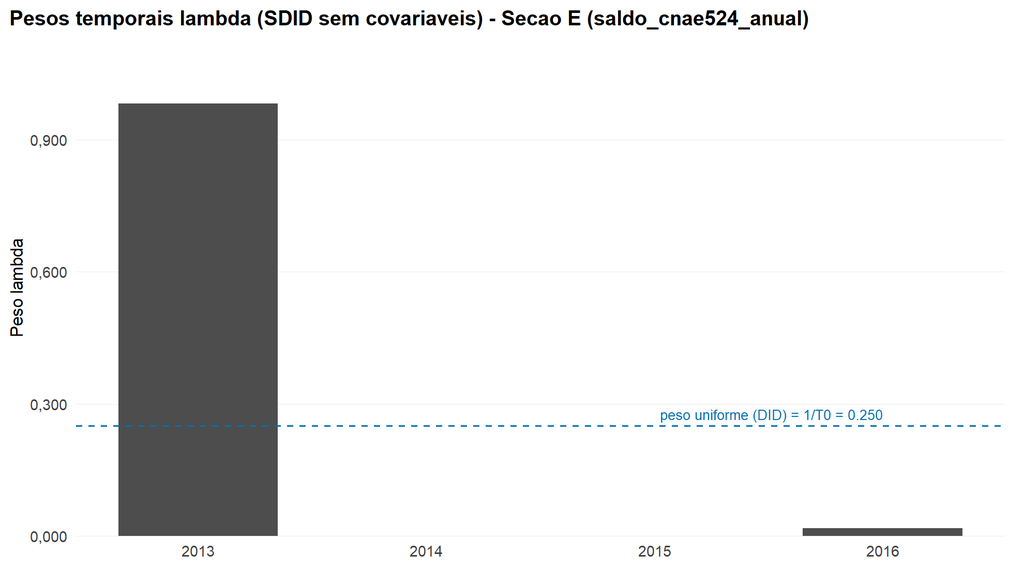

```r
desenhar_pesos_lambda(resultados$E, "E")
```

## 14.6 Event study

```r
tab_event_study(resultados$E)
```

Secao E - event study ano a ano (sem_cov)

| Secao | Variavel | Covariaveis | Ano | Periodo | Efeito_estimado | Erro_Padrao | Estatistica_t | P_valor | IC95_Inferior | IC95_Superior | Banda_placebo_Inferior | Banda_placebo_Superior | Significancia |
| --- | --- | --- | --- | --- | --- | --- | --- | --- | --- | --- | --- | --- | --- |
| E | saldo_cnae524_anual | sem_cov | 2013 | Pre | -0.0602 | 22.3063 | -0.003 | 0.941 | -43.7805 | 43.6602 | -55.5915 | 1.3262 |  |
| E | saldo_cnae524_anual | sem_cov | 2014 | Pre | 12.8480 | 52.0179 | 0.247 | 0.529 | -89.1071 | 114.8031 | -77.7945 | 106.8416 |  |
| E | saldo_cnae524_anual | sem_cov | 2015 | Pre | 53.9768 | 43.1417 | 1.251 | 0.176 | -30.5808 | 138.5345 | -111.6957 | 29.1887 |  |
| E | saldo_cnae524_anual | sem_cov | 2016 | Pre | 3.2275 | 138.0354 | 0.023 | 0.941 | -267.3218 | 273.7768 | -70.7840 | 330.8623 |  |
| E | saldo_cnae524_anual | sem_cov | 2017 | Pos | 153.3061 | 33.9686 | 4.513 | 0.059 | 86.7276 | 219.8847 | -89.7697 | 31.2778 | * |
| E | saldo_cnae524_anual | sem_cov | 2018 | Pos | 55.5521 | 24.1315 | 2.302 | 0.118 | 8.2544 | 102.8498 | -63.1404 | 15.7091 |  |
| E | saldo_cnae524_anual | sem_cov | 2019 | Pos | 11.7254 | 25.9992 | 0.451 | 0.529 | -39.2331 | 62.6838 | -52.4849 | 43.8271 |  |
| E | saldo_cnae524_anual | sem_cov | 2020 | Pos | -103.8817 | 89.5031 | -1.161 | 0.176 | -279.3079 | 71.5444 | -208.0356 | 120.2477 |  |
| E | saldo_cnae524_anual | sem_cov | 2021 | Pos | 172.7743 | 24.7222 | 6.989 | 0.059 | 124.3187 | 221.2298 | -62.5914 | 18.4160 | * |
| E | saldo_cnae524_anual | sem_cov | 2022 | Pos | -0.8776 | 22.5763 | -0.039 | 0.882 | -45.1272 | 43.3720 | -54.3129 | 24.0801 |  |
| E | saldo_cnae524_anual | sem_cov | 2023 | Pos | 7.3484 | 26.0200 | 0.282 | 0.471 | -43.6507 | 58.3476 | -51.6276 | 44.6063 |  |

```r
tab_testes_permutacao(resultados$E)
```

Secao E - testes por permutacao

| Teste | Estatistica | P_valor | Significancia |
| --- | --- | --- | --- |
| Pre-tendencia (conjunto, RMSPE pre) | 27.7893 | 0.353 |  |
| Razao RMSPE pos/pre (Abadie 2010) | 3.5317 | 0.176 |  |
| RMSPE pre-tratamento (tratado) | 27.7893 | NA |  |

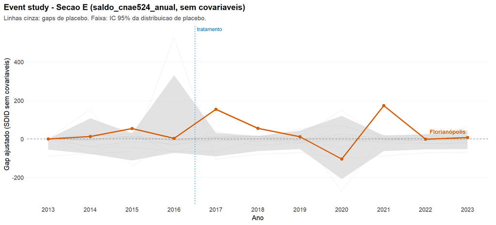

```r
desenhar_event_study(resultados$E, "E")
```

## 14.7 Razão MSPE pós/pré

```r
tab_razao_mspe(razao_mspe_secao(resultados$E, "E"), "E")
```

Secao E - razao MSPE pos/pre (Abadie 2010). Tratado = Florianópolis; distribuicao nula com 16 placebo(s).

| Metrica | Valor |
| --- | --- |
| MSPE pre | 772.2468 |
| MSPE pre (ponderado por lambda) | 0.1942 |
| MSPE pos | 9631.9167 |
| Razao pos/pre | 12.4726 |
| Razao pos/pre (lambda) | 49595.1513 |
| Razao RMSPE | 3.5317 |
| Posto do tratado | 3.0000 |
| P-valor por permutacao | 0.1765 |

```r
tab_ranking_mspe(razao_mspe_secao(resultados$E, "E"), "E")
```

Secao E - maiores razoes MSPE pos/pre

| Posto | Unidade | MSPE_pre | MSPE_pos | Razao | Razao_lambda | Status |
| --- | --- | --- | --- | --- | --- | --- |
| 1 | São Bernardo do Campo | 80.79096 | 3270.97211 | 40.487 | 6909.799 |  |
| 2 | Ribeirão Preto | 434.50869 | 10854.35872 | 24.981 | 551.683 |  |
| 3 | Florianópolis (tratado) | 772.24676 | 9631.91671 | 12.473 | 49595.151 |  |
| 4 | Indaiatuba | 34.65624 | 141.88034 | 4.094 | 143.871 |  |
| 5 | Presidente Prudente | 55.76451 | 125.18756 | 2.245 | 462.144 |  |
| 6 | Jundiaí | 61.54476 | 120.40053 | 1.956 | 64.555 |  |
| 7 | Parnamirim | 583.34682 | 1005.18504 | 1.723 | 85.037 |  |
| 8 | Americana | 33.32354 | 43.02355 | 1.291 | 192.837 |  |
| 9 | Belo Horizonte | 1915.23552 | 2367.93458 | 1.236 | 30.251 |  |
| 10 | Diadema | 35.22934 | 39.18157 | 1.112 | 89.324 |  |
| 11 | Cuiabá | 76.48097 | 74.84716 | 0.979 | 280.114 |  |
| 12 | Chapecó | 217.54726 | 94.32888 | 0.434 | 206.465 |  |
| 13 | Maringá | 1827.23730 | 615.99679 | 0.337 | 31.965 |  |
| 14 | Jaboatão dos Guararapes | 241.22257 | 64.97852 | 0.269 | 150.361 |  |
| 15 | Carapicuíba | 1621.13277 | 413.42065 | 0.255 | 4.020 |  |

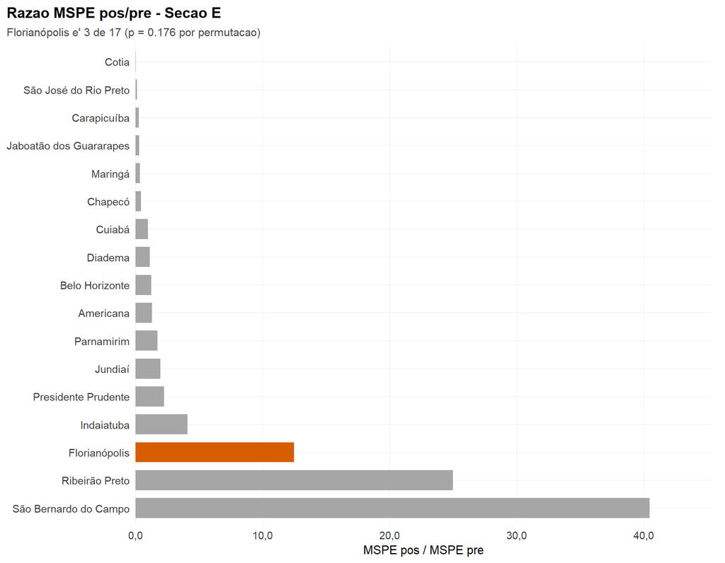

```r
desenhar_razao_mspe(razao_mspe_secao(resultados$E, "E"), "E")
```

## 14.8 Leave-one-out

```r
tab_loo(resultados$E)
```

Secao E - leave-one-out sem covariaveis (sem_cov): 15 unidades mais influentes (de 16)

| Covariaveis | Municipio | Peso_omega_original | ATT_original | ATT_sem_unidade | Delta_ATT | Delta_pct |
| --- | --- | --- | --- | --- | --- | --- |
| sem_cov | Ribeirão Preto | 0.0712 | 42.2781 | 39.8479 | -2.4302 | -5.75 |
| sem_cov | São Bernardo do Campo | 0.0710 | 42.2781 | 43.8581 | 1.5800 | 3.74 |
| sem_cov | Carapicuíba | 0.0851 | 42.2781 | 40.9080 | -1.3702 | -3.24 |
| sem_cov | Belo Horizonte | 0.0639 | 42.2781 | 43.3840 | 1.1058 | 2.62 |
| sem_cov | Cuiabá | 0.0699 | 42.2781 | 42.7680 | 0.4899 | 1.16 |
| sem_cov | Presidente Prudente | 0.0695 | 42.2781 | 42.6347 | 0.3565 | 0.84 |
| sem_cov | Chapecó | 0.0637 | 42.2781 | 41.9511 | -0.3270 | -0.77 |
| sem_cov | São José do Rio Preto | 0.0020 | 42.2781 | 42.0827 | -0.1954 | -0.46 |
| sem_cov | Jundiaí | 0.0679 | 42.2781 | 42.1142 | -0.1640 | -0.39 |
| sem_cov | Cotia | 0.0178 | 42.2781 | 42.4362 | 0.1581 | 0.37 |
| sem_cov | Americana | 0.0679 | 42.2781 | 42.4264 | 0.1482 | 0.35 |
| sem_cov | Jaboatão dos Guararapes | 0.0716 | 42.2781 | 42.4235 | 0.1453 | 0.34 |
| sem_cov | Diadema | 0.0684 | 42.2781 | 42.1408 | -0.1374 | -0.32 |
| sem_cov | Indaiatuba | 0.0679 | 42.2781 | 42.1839 | -0.0943 | -0.22 |
| sem_cov | Maringá | 0.0770 | 42.2781 | 42.3567 | 0.0786 | 0.19 |

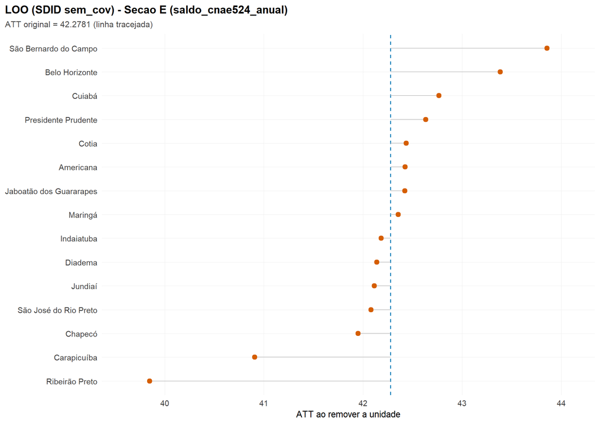

```r
desenhar_loo(resultados$E, "E")
```

## 14.9 Trajetória do ATT com pool escalonado

```r
trajetoria_E <- trajetoria_escalonada_secao("E")
tab_trajetoria_escalonada(trajetoria_E, "E")
```

E - ATT por horizonte sob pool escalonado (ainda-nao-tratado)

| Horizonte | N_controles | ATT | Efeito_pct | Erro_Padrao | Estatistica_t | P_valor | Significancia |
| --- | --- | --- | --- | --- | --- | --- | --- |
| 2019 | 16 | 71.8296 | 71.83 | 24.0122 | 2.991 | 0.003 | *** |
| 2021 | 16 | 57.9734 | 57.97 | 35.3918 | 1.638 | 0.101 |  |
| 2022 | 16 | 48.1251 | 48.13 | 31.2657 | 1.539 | 0.124 |  |
| 2023 | 16 | 42.2781 | 42.28 | 23.8296 | 1.774 | 0.076 | * |

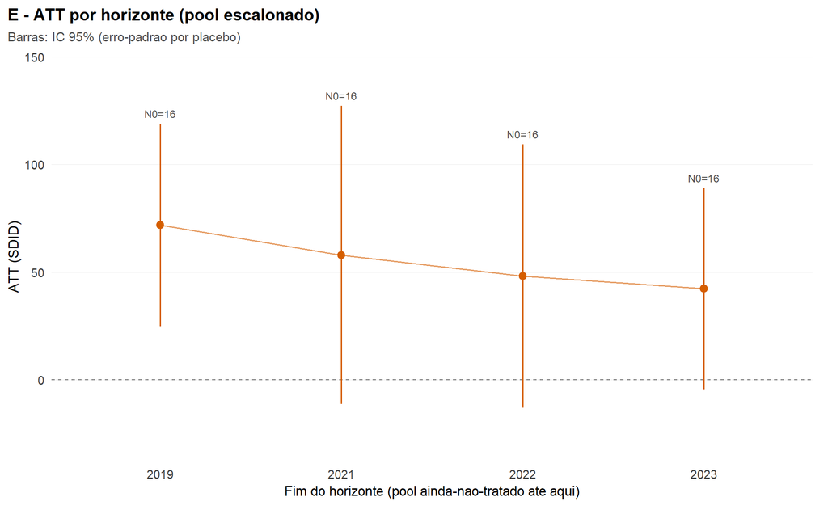

```r
desenhar_trajetoria_escalonada(trajetoria_E, "E")
```

```r
tab_comparacao_sdid(trajetoria_E, "E")
```

E - SDID principal x versoes escalonadas

| Especificacao | N0 | T_pos | ATT | Efeito_pct | Erro_Padrao | Estatistica_t | P_valor | RMSE_pre | Delta_ATT | Sinal_igual | Principal_no_IC95 | Significancia |
| --- | --- | --- | --- | --- | --- | --- | --- | --- | --- | --- | --- | --- |
| Principal (binario) | 16 | 7 | 42.2781 | 42.28 | 23.8296 | 1.774 | 0.076 | 27.7893 | NA | NA | NA | * |
| Escalonado · pool ate 2019 | 16 | 3 | 71.8296 | 71.83 | 24.0122 | 2.991 | 0.003 | 25.7580 | 29.5515 | TRUE | TRUE | *** |
| Escalonado · pool ate 2021 | 16 | 5 | 57.9734 | 57.97 | 35.3918 | 1.638 | 0.101 | 27.4974 | 15.6952 | TRUE | TRUE |  |
| Escalonado · pool ate 2022 | 16 | 6 | 48.1251 | 48.13 | 31.2657 | 1.539 | 0.124 | 27.6530 | 5.8469 | TRUE | TRUE |  |
| Escalonado · pool ate 2023 | 16 | 7 | 42.2781 | 42.28 | 23.8296 | 1.774 | 0.076 | 27.7893 | 0.0000 | TRUE | TRUE | * |

## 14.10 Diagramas do `synthdid`

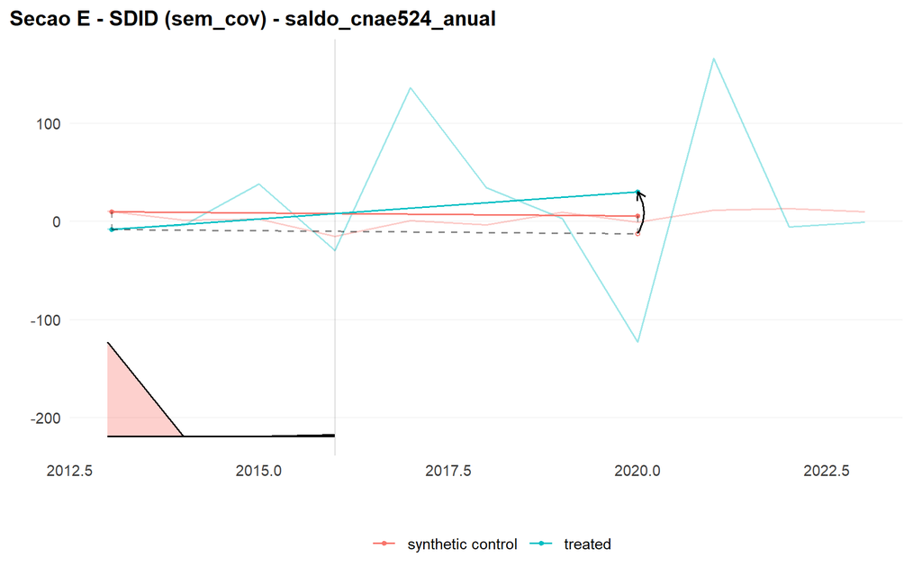

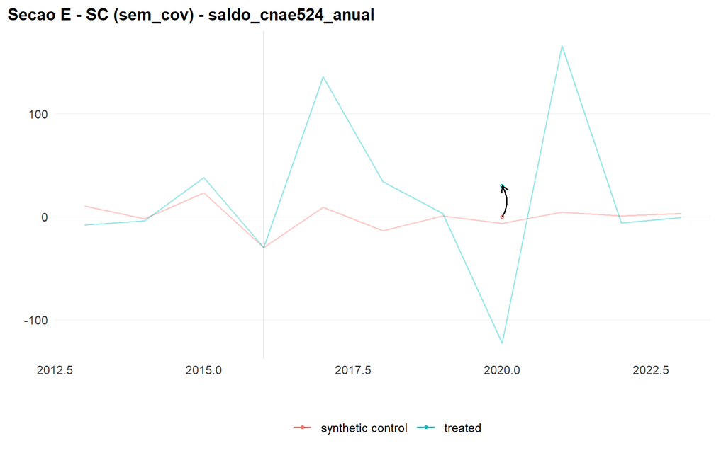

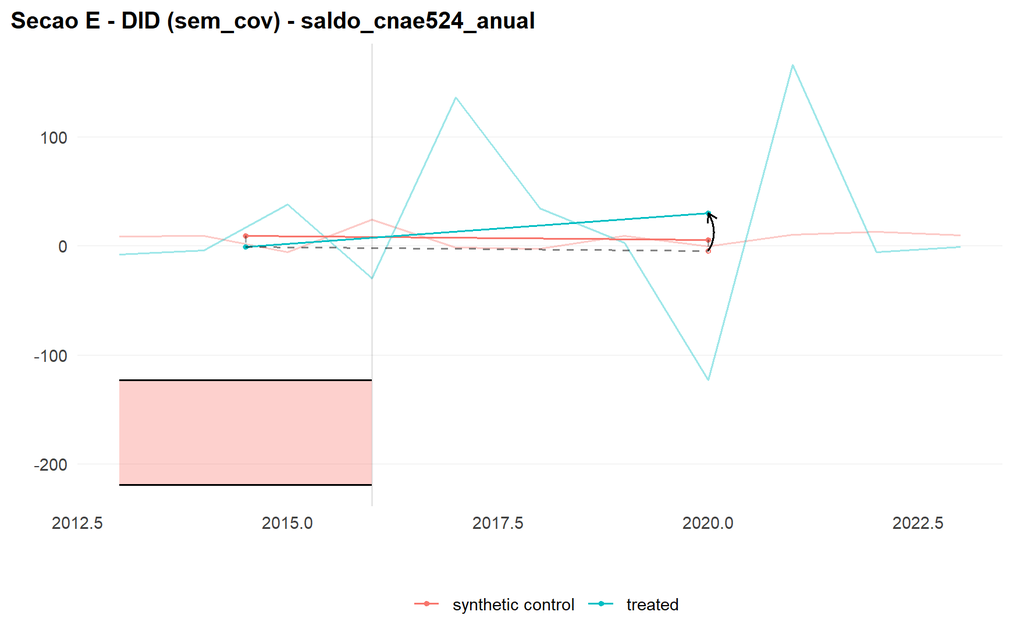

```r
exibir_estimativas_nativas(resultados$E, "E")
```

# 15 Resultados consolidados

Tabelas das seções A, B e E lado a lado. Os cenários com pool restrito ficam de fora, pois são análises de sensibilidade.

```r
stopifnot(
  "nenhuma secao foi executada" = length(resultados) > 0,
  "alguma secao retornou NULL"  = !any(vapply(resultados, is.null, logical(1)))
)
secoes_faltando <- setdiff(names(secoes), names(resultados))
resultados_todos <- resultados
if (length(secoes_faltando) > 0) {
  warning("Secoes nao executadas nesta sessao: ", paste(secoes_faltando, collapse = ", "),
          " - as tabelas consolidadas abaixo cobrem apenas as secoes disponiveis.")
}

ids_consolidados <- setdiff(names(secoes),
                            if (exists("SECOES_SENSIBILIDADE")) SECOES_SENSIBILIDADE else character(0))
resultados <- resultados[intersect(ids_consolidados, names(resultados))]
```

## 15.1 ATT

```r
tab_consolidada <- construir_tabela_consolidada(resultados)
exportar_csv(tab_consolidada,
             file.path(DIR_SAIDA, "resultados_consolidados.csv"),
             "Tabela consolidada")

if (!is.null(tab_consolidada)) {
  knitr::kable(tab_consolidada, digits = 4, row.names = FALSE,
               caption = "Resultados consolidados - SDID / SC / DID por secao")
}
```

Resultados consolidados - SDID / SC / DID por secao

| Grupo | Secao | Variavel | Covariaveis | Modelo | Coeficiente | Efeito_pct | Erro_Padrao | Estatistica_t | P_valor | SE_placebo | IC95_quantil | Significancia |
| --- | --- | --- | --- | --- | --- | --- | --- | --- | --- | --- | --- | --- |
| Macroeconomicas e de renda | A | log_pib_per_capita | sem_cov | SDID | -0.0714 | -6.89 | 0.1051 | -0.679 | 0.497 | exaustivo | [-0.267; 0.087] |  |
| Macroeconomicas e de renda | A | log_pib_per_capita | sem_cov | SC | -0.0349 | -3.43 | 0.1294 | -0.270 | 0.787 | exaustivo | [-0.357; 0.148] |  |
| Macroeconomicas e de renda | A | log_pib_per_capita | sem_cov | DID | -0.0619 | -6.01 | 0.1140 | -0.544 | 0.587 | exaustivo | [-0.285; 0.090] |  |
| Macroeconomicas e de renda | A | log_pib_per_capita | event_study | RMSPE_ratio | 28.4118 | NA | NA | NA | 0.072 | NA | NA | * |
| Macroeconomicas e de renda | A | log_pib_per_capita | sem_cov | SDID (SE jackknife via LOO) | -0.0714 | -6.89 | 0.0121 | -5.876 | 0.000 | NA | NA | *** |
| Macroeconomicas e de renda | B | log_pib_servicos_per_capita | sem_cov | SDID | -0.0210 | -2.08 | 0.0936 | -0.225 | 0.822 | exaustivo | [-0.233; 0.105] |  |
| Macroeconomicas e de renda | B | log_pib_servicos_per_capita | sem_cov | SC | 0.0373 | 3.80 | 0.1148 | 0.325 | 0.745 | exaustivo | [-0.274; 0.202] |  |
| Macroeconomicas e de renda | B | log_pib_servicos_per_capita | sem_cov | DID | -0.0174 | -1.73 | 0.1012 | -0.172 | 0.863 | exaustivo | [-0.257; 0.134] |  |
| Macroeconomicas e de renda | B | log_pib_servicos_per_capita | event_study | RMSPE_ratio | 10.1340 | NA | NA | NA | 0.304 | NA | NA |  |
| Macroeconomicas e de renda | B | log_pib_servicos_per_capita | sem_cov | SDID (SE jackknife via LOO) | -0.0210 | -2.08 | 0.0124 | -1.702 | 0.089 | NA | NA | * |
| Emprego formal | E | saldo_cnae524_anual | sem_cov | SDID | 42.2781 | 42.28 | 23.8296 | 1.774 | 0.076 | exaustivo | [21.433; 107.513] | * |
| Emprego formal | E | saldo_cnae524_anual | sem_cov | SC | 30.0458 | 30.05 | 10.8373 | 2.772 | 0.006 | exaustivo | [6.967; 45.459] | *** |
| Emprego formal | E | saldo_cnae524_anual | sem_cov | DID | 34.5625 | 34.56 | 45.3072 | 0.763 | 0.446 | exaustivo | [-18.180; 143.101] |  |
| Emprego formal | E | saldo_cnae524_anual | event_study | RMSPE_ratio | 3.5317 | NA | NA | NA | 0.176 | NA | NA |  |
| Emprego formal | E | saldo_cnae524_anual | sem_cov | SDID (SE jackknife via LOO) | 42.2781 | 42.28 | 3.3702 | 12.545 | 0.000 | NA | NA | *** |

## 15.2 Leave-one-out

```r
tab_loo_geral <- construir_tabela_loo(resultados)
exportar_csv(tab_loo_geral,
             file.path(DIR_SAIDA, "loo_sdid.csv"),
             "Tabela LOO consolidada")

if (!is.null(tab_loo_geral)) {
  knitr::kable(head(tab_loo_geral, 15), digits = 4, row.names = FALSE,
               caption = "Leave-one-out - 15 unidades mais influentes (todas as secoes)")
}
```

Leave-one-out - 15 unidades mais influentes (todas as secoes)

| Grupo | Secao | Variavel | Covariaveis | Covariaveis.1 | Municipio | Peso_omega_original | ATT_original | ATT_sem_unidade | Delta_ATT | Delta_pct |
| --- | --- | --- | --- | --- | --- | --- | --- | --- | --- | --- |
| Macroeconomicas e de renda | A | log_pib_per_capita | sem_cov | sem_cov | Mauá | 0.0203 | -0.0714 | -0.0663 | 0.0051 | 7.10 |
| Macroeconomicas e de renda | A | log_pib_per_capita | sem_cov | sem_cov | Niterói | 0.0147 | -0.0714 | -0.0672 | 0.0041 | 5.79 |
| Macroeconomicas e de renda | A | log_pib_per_capita | sem_cov | sem_cov | Itajaí | 0.0168 | -0.0714 | -0.0675 | 0.0038 | 5.39 |
| Macroeconomicas e de renda | A | log_pib_per_capita | sem_cov | sem_cov | Itapevi | 0.0201 | -0.0714 | -0.0750 | -0.0036 | -5.11 |
| Macroeconomicas e de renda | A | log_pib_per_capita | sem_cov | sem_cov | Indaiatuba | 0.0158 | -0.0714 | -0.0681 | 0.0032 | 4.52 |
| Macroeconomicas e de renda | A | log_pib_per_capita | sem_cov | sem_cov | Blumenau | 0.0182 | -0.0714 | -0.0736 | -0.0023 | -3.21 |
| Macroeconomicas e de renda | A | log_pib_per_capita | sem_cov | sem_cov | Juazeiro | 0.0196 | -0.0714 | -0.0691 | 0.0022 | 3.13 |
| Macroeconomicas e de renda | A | log_pib_per_capita | sem_cov | sem_cov | Embu das Artes | 0.0186 | -0.0714 | -0.0693 | 0.0021 | 2.93 |
| Macroeconomicas e de renda | A | log_pib_per_capita | sem_cov | sem_cov | Serra | 0.0154 | -0.0714 | -0.0693 | 0.0020 | 2.87 |
| Macroeconomicas e de renda | A | log_pib_per_capita | sem_cov | sem_cov | São João de Meriti | 0.0144 | -0.0714 | -0.0733 | -0.0019 | -2.73 |
| Macroeconomicas e de renda | A | log_pib_per_capita | sem_cov | sem_cov | Nova Iguaçu | 0.0153 | -0.0714 | -0.0732 | -0.0019 | -2.64 |
| Macroeconomicas e de renda | A | log_pib_per_capita | sem_cov | sem_cov | Suzano | 0.0231 | -0.0714 | -0.0695 | 0.0019 | 2.62 |
| Macroeconomicas e de renda | A | log_pib_per_capita | sem_cov | sem_cov | Duque de Caxias | 0.0227 | -0.0714 | -0.0696 | 0.0018 | 2.51 |
| Macroeconomicas e de renda | A | log_pib_per_capita | sem_cov | sem_cov | Olinda | 0.0137 | -0.0714 | -0.0730 | -0.0017 | -2.34 |
| Macroeconomicas e de renda | A | log_pib_per_capita | sem_cov | sem_cov | Santa Luzia | 0.0107 | -0.0714 | -0.0697 | 0.0016 | 2.26 |

## 15.3 Event study

```r
tab_es_geral <- construir_tabela_event_study_geral(resultados, ANO_TRATAMENTO)
exportar_csv(tab_es_geral,
             file.path(DIR_SAIDA, "event_study_consolidado.csv"),
             "Tabela event study consolidada")

if (!is.null(tab_es_geral)) {
  knitr::kable(tab_es_geral, digits = 4, row.names = FALSE,
               caption = "Event study - seções A, B e E")
}
```

Event study - seções A, B e E

| Grupo | Secao | Variavel | Covariaveis | Ano | Periodo | Efeito_estimado | Erro_Padrao | Estatistica_t | P_valor | IC95_Inferior | IC95_Superior | Banda_placebo_Inferior | Banda_placebo_Superior | Significancia |
| --- | --- | --- | --- | --- | --- | --- | --- | --- | --- | --- | --- | --- | --- | --- |
| Macroeconomicas e de renda | A | log_pib_per_capita | sem_cov | 2013 | Pre | -0.0021 | 0.0264 | -0.081 | 0.884 | -0.0540 | 0.0497 | -0.0551 | 0.0634 |  |
| Macroeconomicas e de renda | A | log_pib_per_capita | sem_cov | 2014 | Pre | 0.0047 | 0.0376 | 0.125 | 0.768 | -0.0690 | 0.0784 | -0.0346 | 0.0597 |  |
| Macroeconomicas e de renda | A | log_pib_per_capita | sem_cov | 2015 | Pre | -0.0023 | 0.0108 | -0.212 | 0.710 | -0.0235 | 0.0189 | -0.0141 | 0.0223 |  |
| Macroeconomicas e de renda | A | log_pib_per_capita | sem_cov | 2016 | Pre | 0.0039 | 0.0254 | 0.153 | 0.754 | -0.0460 | 0.0538 | -0.0391 | 0.0677 |  |
| Macroeconomicas e de renda | A | log_pib_per_capita | sem_cov | 2017 | Pos | -0.0092 | 0.0584 | -0.158 | 0.812 | -0.1238 | 0.1053 | -0.1012 | 0.1516 |  |
| Macroeconomicas e de renda | A | log_pib_per_capita | sem_cov | 2018 | Pos | 0.0077 | 0.0937 | 0.082 | 0.899 | -0.1759 | 0.1913 | -0.1347 | 0.1844 |  |
| Macroeconomicas e de renda | A | log_pib_per_capita | sem_cov | 2019 | Pos | -0.0153 | 0.0978 | -0.157 | 0.870 | -0.2071 | 0.1765 | -0.1438 | 0.1876 |  |
| Macroeconomicas e de renda | A | log_pib_per_capita | sem_cov | 2020 | Pos | -0.0671 | 0.1023 | -0.656 | 0.478 | -0.2677 | 0.1334 | -0.1599 | 0.2286 |  |
| Macroeconomicas e de renda | A | log_pib_per_capita | sem_cov | 2021 | Pos | -0.1131 | 0.1673 | -0.676 | 0.449 | -0.4411 | 0.2149 | -0.2948 | 0.3893 |  |
| Macroeconomicas e de renda | A | log_pib_per_capita | sem_cov | 2022 | Pos | -0.1911 | 0.1742 | -1.097 | 0.217 | -0.5325 | 0.1503 | -0.2503 | 0.2916 |  |
| Macroeconomicas e de renda | A | log_pib_per_capita | sem_cov | 2023 | Pos | -0.1113 | 0.1627 | -0.684 | 0.348 | -0.4303 | 0.2077 | -0.2780 | 0.3272 |  |
| Macroeconomicas e de renda | B | log_pib_servicos_per_capita | sem_cov | 2013 | Pre | -0.0029 | 0.0357 | -0.082 | 0.826 | -0.0730 | 0.0671 | -0.0674 | 0.0747 |  |
| Macroeconomicas e de renda | B | log_pib_servicos_per_capita | sem_cov | 2014 | Pre | 0.0056 | 0.0326 | 0.172 | 0.594 | -0.0584 | 0.0696 | -0.0744 | 0.0358 |  |
| Macroeconomicas e de renda | B | log_pib_servicos_per_capita | sem_cov | 2015 | Pre | -0.0042 | 0.0158 | -0.266 | 0.739 | -0.0351 | 0.0268 | -0.0323 | 0.0295 |  |
| Macroeconomicas e de renda | B | log_pib_servicos_per_capita | sem_cov | 2016 | Pre | 0.0010 | 0.0174 | 0.056 | 0.884 | -0.0331 | 0.0350 | -0.0279 | 0.0284 |  |
| Macroeconomicas e de renda | B | log_pib_servicos_per_capita | sem_cov | 2017 | Pos | 0.0020 | 0.0669 | 0.030 | 0.971 | -0.1291 | 0.1332 | -0.1348 | 0.1097 |  |
| Macroeconomicas e de renda | B | log_pib_servicos_per_capita | sem_cov | 2018 | Pos | 0.0178 | 0.0921 | 0.193 | 0.884 | -0.1627 | 0.1982 | -0.1554 | 0.1866 |  |
| Macroeconomicas e de renda | B | log_pib_servicos_per_capita | sem_cov | 2019 | Pos | -0.0062 | 0.0972 | -0.064 | 0.986 | -0.1967 | 0.1842 | -0.1476 | 0.2010 |  |
| Macroeconomicas e de renda | B | log_pib_servicos_per_capita | sem_cov | 2020 | Pos | -0.0516 | 0.1241 | -0.416 | 0.638 | -0.2948 | 0.1916 | -0.1900 | 0.2802 |  |
| Macroeconomicas e de renda | B | log_pib_servicos_per_capita | sem_cov | 2021 | Pos | -0.0671 | 0.1598 | -0.420 | 0.638 | -0.3803 | 0.2461 | -0.2376 | 0.3249 |  |
| Emprego formal | E | saldo_cnae524_anual | sem_cov | 2013 | Pre | -0.0602 | 22.3063 | -0.003 | 0.941 | -43.7805 | 43.6602 | -55.5915 | 1.3262 |  |
| Emprego formal | E | saldo_cnae524_anual | sem_cov | 2014 | Pre | 12.8480 | 52.0179 | 0.247 | 0.529 | -89.1071 | 114.8031 | -77.7945 | 106.8416 |  |
| Emprego formal | E | saldo_cnae524_anual | sem_cov | 2015 | Pre | 53.9768 | 43.1417 | 1.251 | 0.176 | -30.5808 | 138.5345 | -111.6957 | 29.1887 |  |
| Emprego formal | E | saldo_cnae524_anual | sem_cov | 2016 | Pre | 3.2275 | 138.0354 | 0.023 | 0.941 | -267.3218 | 273.7768 | -70.7840 | 330.8623 |  |
| Emprego formal | E | saldo_cnae524_anual | sem_cov | 2017 | Pos | 153.3061 | 33.9686 | 4.513 | 0.059 | 86.7276 | 219.8847 | -89.7697 | 31.2778 | * |
| Emprego formal | E | saldo_cnae524_anual | sem_cov | 2018 | Pos | 55.5521 | 24.1315 | 2.302 | 0.118 | 8.2544 | 102.8498 | -63.1404 | 15.7091 |  |
| Emprego formal | E | saldo_cnae524_anual | sem_cov | 2019 | Pos | 11.7254 | 25.9992 | 0.451 | 0.529 | -39.2331 | 62.6838 | -52.4849 | 43.8271 |  |
| Emprego formal | E | saldo_cnae524_anual | sem_cov | 2020 | Pos | -103.8817 | 89.5031 | -1.161 | 0.176 | -279.3079 | 71.5444 | -208.0356 | 120.2477 |  |
| Emprego formal | E | saldo_cnae524_anual | sem_cov | 2021 | Pos | 172.7743 | 24.7222 | 6.989 | 0.059 | 124.3187 | 221.2298 | -62.5914 | 18.4160 | * |
| Emprego formal | E | saldo_cnae524_anual | sem_cov | 2022 | Pos | -0.8776 | 22.5763 | -0.039 | 0.882 | -45.1272 | 43.3720 | -54.3129 | 24.0801 |  |
| Emprego formal | E | saldo_cnae524_anual | sem_cov | 2023 | Pos | 7.3484 | 26.0200 | 0.282 | 0.471 | -43.6507 | 58.3476 | -51.6276 | 44.6063 |  |

## 15.4 Razão MSPE pós/pré

A razão em si não é comparável entre seções, porque depende da escala da variável e do tamanho das janelas. O que se compara é a posição de Florianópolis na distribuição de placebo de cada seção.

```r
tab_mspe_geral <- construir_tabela_razao_mspe(resultados)
exportar_csv(tab_mspe_geral,
             file.path(DIR_SAIDA, "razao_mspe_consolidada.csv"),
             "Tabela de razao MSPE consolidada")

if (is.null(tab_mspe_geral)) {
  aviso_indisponivel("Nenhuma secao com event study disponivel.")
} else {
  knitr::kable(tab_mspe_geral, digits = 4, row.names = FALSE,
               caption = "Razão MSPE pós/pré - seções A, B e E")
}
```

Razão MSPE pós/pré - seções A, B e E

| Grupo | Secao | Variavel | Covariaveis | MSPE_pre | MSPE_pos | Razao | Razao_lambda | Posto | N_unidades | P_valor |
| --- | --- | --- | --- | --- | --- | --- | --- | --- | --- | --- |
| Macroeconomicas e de renda | A | log_pib_per_capita | sem_cov | 0.0000 | 0.0095 | 807.2331 | 990.6982 | 5 | 69 | 0.0725 |
| Macroeconomicas e de renda | B | log_pib_servicos_per_capita | sem_cov | 0.0000 | 0.0015 | 102.6986 | 120.9109 | 21 | 69 | 0.3043 |
| Emprego formal | E | saldo_cnae524_anual | sem_cov | 772.2468 | 9631.9167 | 12.4726 | 49595.1513 | 3 | 17 | 0.1765 |

# 16 Reprodutibilidade

Tabelas e gráficos exportados em `outputs/`:

```r
arquivos_gerados <- list.files(DIR_SAIDA, pattern = "\\.(csv|png)$", recursive = TRUE)
arquivos_gerados <- arquivos_gerados[
  file.mtime(file.path(DIR_SAIDA, arquivos_gerados)) >= INICIO_EXECUCAO]
knitr::kable(data.frame(Arquivo = arquivos_gerados),
             caption = sprintf("Arquivos gerados nesta execução em %s (%d)",
                               DIR_SAIDA, length(arquivos_gerados)))
```

Arquivos gerados nesta execução em outputs (196)

| Arquivo |
| --- |
| composicao_pool_criterios.csv |
| configuracao_covariaveis.csv |
| coordenadas_aeroportos.csv |
| event_study_consolidado.csv |
| loo_sdid.csv |
| misto_comparacao_att.csv |
| misto_grade_caliper.csv |
| misto_omega_diagnostico.csv |
| misto_pool.csv |
| piso_volume_cnae524.csv |
| pool_por_modo_exclusao_AD.csv |
| pools_turismo_tecnologia_misto.csv |
| razao_mspe_consolidada.csv |
| resultados_consolidados.csv |
| Secao_A/configuracao_covariaveis.csv |
| Secao_A/estimativa_sem_cov_did.png |
| Secao_A/estimativa_sem_cov_sc.png |
| Secao_A/estimativa_sem_cov_sdid.png |
| Secao_A/event_study.csv |
| Secao_A/event_study.png |
| Secao_A/loo_sdid.csv |
| Secao_A/loo_sdid.png |
| Secao_A/pesos_sdid.csv |
| Secao_A/pib_per_capita_anual_comparacao_escalonado.csv |
| Secao_A/razao_mspe.csv |
| Secao_A/razao_mspe.png |
| Secao_A/resultados.csv |
| Secao_A_esc_h1/configuracao_covariaveis.csv |
| Secao_A_esc_h1/estimativa_sem_cov_did.png |
| Secao_A_esc_h1/estimativa_sem_cov_sc.png |

[output cut: 166 more lines]